# The Long Reach of Childhood Income Inequality: A Multinational Twin Study of Gene-Environment Interplay on Adult Depressive Symptoms

Analytic code with outputs for subsample with genotyping (R version 4.4.2)

Author

Affiliation

Chandra A Reynolds

University of Colorado Boulder

Published

August 19, 2025

Abstract

We examine the importance of childhood exposure to uneven distribution of income (i.e., income inequality) in shaping individual differences in adult depressive symptoms, and we test for interplay between genes and inequality using polygenic indices for major depressive disorder as well as estimates of genetic influences based on twin models. Research participants were 69,973 members of twin studies from four developed countries born between 1893 and 1979, and aged 26 to 103 at the time of assessment of depressive symptoms. Income inequality exposure was operationalized as the share of income accruing to the top 1% for each country when the participant was age 10. Income inequality exposure at age 10 was associated with depressive symptom scores in adulthood, adjusting for a host of covariates. Each 1% rise in inequality was associated with a 0.20 higher T-score standardized depressive symptom score. Further, genotyping was available for 6,251 participants. Interaction models showed that among men, but not women, a higher genetic index score for depression augmented the strength of the association between childhood income inequality and depressive symptoms. Twin models based on the entire analytic sample also showed that childhood income inequality moderated genetic variance underlying depressive symptoms, with higher heritability at higher levels of childhood income inequality. Results underscore the long reach of childhood exposure to income inequality and illustrate the interplay of genetic risk with adverse environmental exposures.

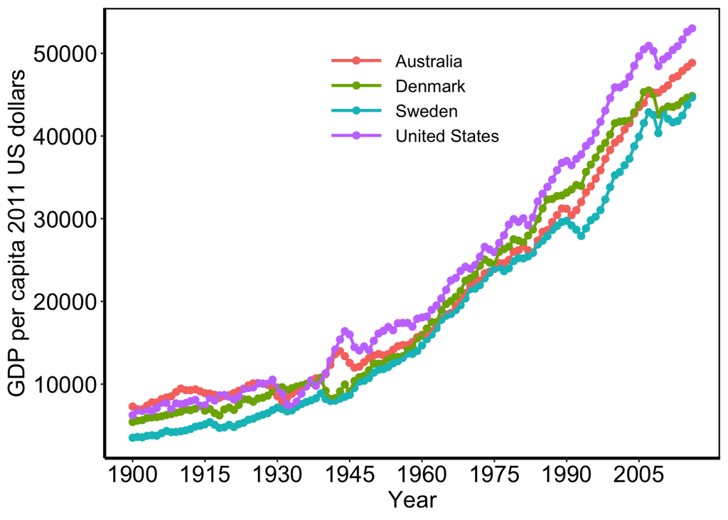

```r
sesplot<-ggplot(ses2, aes(x=year, y=Real_GDP_per_capita_2011US, color=country2)) +
  geom_point(size=2)+
  geom_line(size=1)+
  theme_bw()+
  scale_x_continuous(name="Year", breaks=c(seq(1900,2010,15)))+
  scale_y_continuous(name="GDP per capita 2011 US dollars", breaks=c(seq(0,50000,10000)))+
  theme(legend.box.background=element_blank(),
        legend.background=element_rect(fill="transparent",size=.5),
        axis.text.x=element_text(colour="black", size=16),
        axis.text.y=element_text(colour="black", size=16),
        axis.title.x=element_text(colour="black", size=16),
        axis.title.y=element_text(colour="black", size=16),
        plot.title=element_text(size=14),
        panel.background=element_blank(),
        panel.grid.major=element_blank(),
        panel.grid.minor=element_blank(),
        panel.grid.minor.y=element_blank(),
        panel.grid.major.y=element_blank(),
        panel.grid.major.x=element_blank(),
        panel.grid.minor.x=element_blank(),
        panel.border=element_rect(colour="black", size=1),
        strip.background=element_blank(),
        strip.text=element_text(size=14),
        axis.line.x=element_line(size=1),
        axis.line.y=element_line(size=1),
        legend.text=element_text(size=12),
        legend.key.width=unit(3,"line"),
        legend.title=element_blank(),
        legend.direction="vertical",
        #       plot.title= element_text(hjust=-.45, vjust=2.12),
        legend.position=c(0.5, 0.8),
        legend.key=element_blank())

sesplot
```

## Supplemental Table S1: Descriptive statistics for PGS subsample

```r
# generate a descriptive table with the tbl_summary package ---------------
dtable3 <- data5 %>% select(age_dep, zygosC,country, depression,depression_sqrt, ineq10, gdp10, isced, sexF, year10, yearDEP)

tbl3<-dtable3 %>%
  tbl_summary(
   statistic = list(
      all_continuous() ~ "{mean} ({sd})"
    ),
    digits = all_continuous() ~ 2,
   type = list(isced ~ "continuous"),
    missing = "no",
    label = list(age_dep ~ "Age at first depressive symptom assessment",
                 zygosC ~ "Zygosity",
                 depression ~ "Depressive symptoms",
                 ineq10 ~ "Top 1% at age 10",
                 gdp10 ~ "GDP at age 10",
                 isced ~ "Educational attainment (ISCED)",
                 year10 ~ "Year at age 10",
                 yearDEP ~ "Year at Assessment",
                 country ~ "Country")) |>
  add_ci(pattern = "{stat} ({ci})",
         style_fun = everything() ~ purrr::partial(style_number, digits = 2))

tbl3
```

| **Characteristic** | **N = 6,251** (**95% CI**)<sup>1</sup> |
| --- | --- |
| Age at first depressive symptom assessment | 63.60 (10.70) (63.34, 63.87) |
| Zygosity |  |
| DZ | 2,292 (37%) (0.36%, 0.38%) |
| MZ | 2,779 (45%) (0.43%, 0.46%) |
| OS | 1,168 (19%) (0.18%, 0.20%) |
| Country |  |
| Australia | 1,274 (20%) (0.19%, 0.21%) |
| Denmark | 1,965 (31%) (0.30%, 0.33%) |
| Sweden | 1,732 (28%) (0.27%, 0.29%) |
| VETSA | 1,280 (20%) (0.19%, 0.22%) |
| Depressive symptoms | 21.11 (4.47) (21.00, 21.22) |
| depression_sqrt | 4.57 (0.45) (4.56, 4.58) |
| Top 1% at age 10 | 10.96 (2.42) (10.90, 11.02) |
| GDP at age 10 | 11,938.78 (4,194.66) (11,834.78, 12,042.79) |
| Educational attainment (ISCED) | 3.27 (1.80) (3.22, 3.31) |
| sexF |  |
| Female | 2,884 (46%) (0.45%, 0.47%) |
| Male | 3,367 (54%) (0.53%, 0.55%) |
| Year at age 10 | 1,944.93 (12.80) (1,944.62, 1,945.25) |
| Year at Assessment | 1,998.54 (6.18) (1,998.38, 1,998.69) |

Abbreviation: CI = Confidence Interval  
<sup>1</sup> Mean (SD); n (%)

## MPlus Model Fitting with PGS subsample

## Model 1: Does PGS contribute to depressive symptoms in addition to childhood inequality?

Model 1 results

```r
mod16_out$results$warnings
```

```
list()
attr(,"class")
[1] "mplus.warnings" "list"
```

```r
mod16_out$results$summaries$Observations
```

```
[1] 6251
```

```r
mod16_out$results$sampstat
```

```
$means
    DEPT     T1    T2  SEX0 GDP10C INQ10C R_MDD
1 49.991 -8.516 2.117 0.461 -0.061  0.962     0

$covariances
          DEPT      T1     T2   SEX0 GDP10C INQ10C R_MDD
DEPT   100.105      NA     NA     NA     NA     NA    NA
T1       9.218  61.224     NA     NA     NA     NA    NA
T2       4.446  18.027 17.122     NA     NA     NA    NA
SEX0     0.176   0.730  0.389  0.249     NA     NA    NA
GDP10C  -4.385 -23.084 -9.902 -0.728 17.592     NA    NA
INQ10C   3.890  12.346  6.679  0.165 -6.174  5.862    NA
R_MDD    0.532  -0.065 -0.046  0.002 -0.003 -0.045 0.725

$correlations
         DEPT     T1     T2   SEX0 GDP10C INQ10C R_MDD
DEPT    1.000     NA     NA     NA     NA     NA    NA
T1      0.118  1.000     NA     NA     NA     NA    NA
T2      0.107  0.557  1.000     NA     NA     NA    NA
SEX0    0.035  0.187  0.189  1.000     NA     NA    NA
GDP10C -0.104 -0.703 -0.571 -0.348  1.000     NA    NA
INQ10C  0.161  0.652  0.667  0.137 -0.608  1.000    NA
R_MDD   0.062 -0.010 -0.013  0.006 -0.001 -0.022     1

$univariate.sample.statistics
       Sample Size   Mean Variance Skewness Kurtosis Minimum Maximum  %Min
DEPT          6251 49.991  100.105    1.466    2.278  40.095 106.143 15.12
T1            6251 -8.516   61.224   -0.350   -1.161 -31.100   0.000  0.02
T2            6251  2.117   17.122    2.196    4.542   0.000  29.000 69.56
SEX0          6251  0.461    0.249    0.155   -1.976   0.000   1.000 53.86
GDP10C        6251 -0.061   17.592    0.144   -1.160  -7.781   9.390  0.02
INQ10C        6251  0.962    5.862    2.302   10.915  -3.270  18.060  0.06
R_MDD         6251  0.000    0.725   -0.034    0.863  -3.255   3.327  0.02
        %Max     20%     40% Median    60%    80%
DEPT    0.02  41.684  45.035 46.439 49.491 57.184
T1     31.29 -16.500 -11.500 -8.000 -4.000  0.000
T2      0.02   0.000   0.000  0.000  0.000  4.160
SEX0   46.14   0.000   0.000  0.000  1.000  1.000
GDP10C  0.06  -4.412  -1.709  0.333  1.288  4.945
INQ10C  0.08  -1.008   0.161  0.536  0.672  3.292
R_MDD   0.02  -0.597  -0.145  0.005  0.153  0.587

attr(,"class")
[1] "mplus.sampstat" "list"
```

```r
mod16_out$results$parameters$unstandardized
```

| paramHeader | param | est | se | est_se | pval |
| --- | --- | --- | --- | --- | --- |
| DEPT.ON | T1 | 0.032 | 0.027 | 1.163 | 0.245 |
| DEPT.ON | T2 | -0.013 | 0.048 | -0.267 | 0.789 |
| DEPT.ON | SEX0 | 0.254 | 0.280 | 0.908 | 0.364 |
| DEPT.ON | INQ10C | 0.627 | 0.098 | 6.390 | 0.000 |
| DEPT.ON | GDP10C | 0.016 | 0.056 | 0.282 | 0.778 |
| DEPT.ON | R_MDD | 0.774 | 0.170 | 4.544 | 0.000 |
| Intercepts | DEPT | 49.569 | 0.333 | 148.725 | 0.000 |
| Residual.Variances | DEPT | 97.046 | 2.772 | 35.009 | 0.000 |

```r
mod16_out$results$parameters$ci.unstandardized
```

| paramHeader | param | low.5 | low2.5 | low5 | est | up5 | up2.5 | up.5 |
| --- | --- | --- | --- | --- | --- | --- | --- | --- |
| DEPT.ON | T1 | -0.038 | -0.022 | -0.013 | 0.032 | 0.076 | 0.085 | 0.102 |
| DEPT.ON | T2 | -0.136 | -0.107 | -0.092 | -0.013 | 0.066 | 0.081 | 0.111 |
| DEPT.ON | SEX0 | -0.468 | -0.295 | -0.207 | 0.254 | 0.716 | 0.804 | 0.976 |
| DEPT.ON | INQ10C | 0.374 | 0.435 | 0.466 | 0.627 | 0.788 | 0.819 | 0.880 |
| DEPT.ON | GDP10C | -0.129 | -0.094 | -0.077 | 0.016 | 0.108 | 0.126 | 0.161 |
| DEPT.ON | R_MDD | 0.335 | 0.440 | 0.494 | 0.774 | 1.054 | 1.108 | 1.213 |
| Intercepts | DEPT | 48.710 | 48.916 | 49.021 | 49.569 | 50.117 | 50.222 | 50.427 |
| Residual.Variances | DEPT | 89.906 | 91.613 | 92.486 | 97.046 | 101.607 | 102.480 | 104.187 |

```r
mod16_out$results$summaries
```

| Mplus.version | Title | AnalysisType | DataType | Estimator | Observations | NGroups | NDependentVars | NIndependentVars | NContinuousLatentVars | Parameters | ChiSqM_Value | ChiSqM_DF | ChiSqM_PValue | ChiSqM_ScalingCorrection | ChiSqBaseline_Value | ChiSqBaseline_DF | ChiSqBaseline_PValue | LL | UnrestrictedLL | LLCorrectionFactor | UnrestrictedLLCorrectionFactor | CFI | TLI | AIC | BIC | aBIC | RMSEA_Estimate | RMSEA_90CI_LB | RMSEA_90CI_UB | … |
| --- | --- | --- | --- | --- | --- | --- | --- | --- | --- | --- | --- | --- | --- | --- | --- | --- | --- | --- | --- | --- | --- | --- | --- | --- | --- | --- | --- | --- | --- | --- |
| 8.11 | model 1 childhood inequal & PGS; | COMPLEX | INDIVIDUAL | MLR | 6251 | 1 | 1 | 6 | 0 | 8 | 0 | 0 | 0 | 1 | 142.597 | 6 | 0 | -23169.46 | -23169.46 | 1.4906 | 1.4906 | 1 | 1 | 46354.93 | 46408.85 | 46383.43 | 0 | 0 | 0 | … |

```r
mod16_out$results$tech1$parameterSpecification$BETWEEN
```

```r
mod16_out$results$data_summary
```

```
$overall
  NClusters NMissPatterns AvgClusterSize
1      3570             1             NA

$ICCs
list()

attr(,"class")
[1] "mplus.data_summary" "list"
```

## Model 2: Does PGS moderate the effect of childhood inequality on depressive symptoms?

Model 2 Results

```r
mod17_out$results$warnings
```

```
[[1]]
[1] "Note that only the first 8 characters of variable names are used in the output."
[2] "Shorten variable names to avoid any confusion."
[3] "1 WARNING(S) FOUND IN THE INPUT INSTRUCTIONS"

attr(,"class")
[1] "mplus.warnings" "list"
```

```r
mod17_out$results$summaries$Observations
```

```
[1] 6251
```

```r
mod17_out$results$sampstat
```

```
$means
    DEPT     T1    T2  SEX0 GDP10C INQ10C GDP10C_I R_MDD GDP10C_R INQ10C_R
1 49.991 -8.516 2.117 0.461 -0.061  0.962   -6.233     0   -0.003   -0.046

$covariances
            DEPT      T1      T2   SEX0 GDP10C  INQ10C GDP10C_I  R_MDD GDP10C_R
DEPT     100.105      NA      NA     NA     NA      NA       NA     NA       NA
T1         9.218  61.224      NA     NA     NA      NA       NA     NA       NA
T2         4.446  18.027  17.122     NA     NA      NA       NA     NA       NA
SEX0       0.176   0.730   0.389  0.249     NA      NA       NA     NA       NA
GDP10C    -4.385 -23.084  -9.902 -0.728 17.592      NA       NA     NA       NA
INQ10C     3.890  12.346   6.679  0.165 -6.174   5.862       NA     NA       NA
GDP10C_I -16.560 -39.703 -35.970 -1.149 29.888 -25.297  162.699     NA       NA
R_MDD      0.532  -0.065  -0.046  0.002 -0.003  -0.045    0.062  0.725       NA
GDP10C_R   0.943  -0.272   0.091 -0.018  0.038   0.067   -0.560 -0.057   15.350
INQ10C_R   0.767  -0.117  -0.172 -0.006  0.061  -0.357    2.111  0.802   -4.688
         INQ10C_R
DEPT           NA
T1             NA
T2             NA
SEX0           NA
GDP10C         NA
INQ10C         NA
GDP10C_I       NA
R_MDD          NA
GDP10C_R       NA
INQ10C_R    5.079

$correlations
           DEPT     T1     T2   SEX0 GDP10C INQ10C GDP10C_I  R_MDD GDP10C_R
DEPT      1.000     NA     NA     NA     NA     NA       NA     NA       NA
T1        0.118  1.000     NA     NA     NA     NA       NA     NA       NA
T2        0.107  0.557  1.000     NA     NA     NA       NA     NA       NA
SEX0      0.035  0.187  0.189  1.000     NA     NA       NA     NA       NA
GDP10C   -0.104 -0.703 -0.571 -0.348  1.000     NA       NA     NA       NA
INQ10C    0.161  0.652  0.667  0.137 -0.608  1.000       NA     NA       NA
GDP10C_I -0.130 -0.398 -0.682 -0.181  0.559 -0.819    1.000     NA       NA
R_MDD     0.062 -0.010 -0.013  0.006 -0.001 -0.022    0.006  1.000       NA
GDP10C_R  0.024 -0.009  0.006 -0.009  0.002  0.007   -0.011 -0.017    1.000
INQ10C_R  0.034 -0.007 -0.018 -0.005  0.006 -0.065    0.073  0.418   -0.531
```

[output cut: 23 more lines]

```
INQ10C_RMDD          6251 -0.046    5.079   -3.078   59.419  -37.709  21.122
               %Min  %Max     20%     40% Median    60%    80%
DEPT          15.12  0.02  41.684  45.035 46.439 49.491 57.184
T1             0.02 31.29 -16.500 -11.500 -8.000 -4.000  0.000
T2            69.56  0.02   0.000   0.000  0.000  0.000  4.160
SEX0          53.86 46.14   0.000   0.000  0.000  1.000  1.000
GDP10C         0.02  0.06  -4.412  -1.709  0.333  1.288  4.945
INQ10C         0.06  0.08  -1.008   0.161  0.536  0.672  3.292
GDP10C_INQ10C  0.08  1.42 -11.059  -3.987 -2.110 -1.212  0.527
R_MDD          0.02  0.02  -0.597  -0.145  0.005  0.153  0.587
GDP10C_RMDD    0.02  0.02  -1.910  -0.254 -0.004  0.239  1.829
INQ10C_RMDD    0.02  0.02  -0.618  -0.114  0.000  0.111  0.616

attr(,"class")
[1] "mplus.sampstat" "list"
```

```r
mod17_out$results$parameters$unstandardized
```

| paramHeader | param | est | se | est_se | pval |
| --- | --- | --- | --- | --- | --- |
| DEPT.ON | T1 | 0.036 | 0.031 | 1.145 | 0.252 |
| DEPT.ON | T2 | -0.024 | 0.051 | -0.472 | 0.637 |
| DEPT.ON | SEX0 | 0.273 | 0.281 | 0.974 | 0.330 |
| DEPT.ON | GDP10C | 0.024 | 0.059 | 0.405 | 0.685 |
| DEPT.ON | INQ10C | 0.617 | 0.129 | 4.798 | 0.000 |
| DEPT.ON | GDP10C_INQ | -0.008 | 0.025 | -0.316 | 0.752 |
| DEPT.ON | R_MDD | 0.519 | 0.186 | 2.798 | 0.005 |
| DEPT.ON | GDP10C_RMD | 0.135 | 0.048 | 2.790 | 0.005 |
| DEPT.ON | INQ10C_RMD | 0.240 | 0.083 | 2.881 | 0.004 |
| Intercepts | DEPT | 49.590 | 0.345 | 143.939 | 0.000 |
| Residual.Variances | DEPT | 96.825 | 2.751 | 35.197 | 0.000 |

```r
mod17_out$results$parameters$ci.unstandardized
```

| paramHeader | param | low.5 | low2.5 | low5 | est | up5 | up2.5 | up.5 |
| --- | --- | --- | --- | --- | --- | --- | --- | --- |
| DEPT.ON | T1 | -0.044 | -0.025 | -0.016 | 0.036 | 0.087 | 0.096 | 0.115 |
| DEPT.ON | T2 | -0.156 | -0.124 | -0.108 | -0.024 | 0.060 | 0.076 | 0.108 |
| DEPT.ON | SEX0 | -0.449 | -0.277 | -0.188 | 0.273 | 0.735 | 0.823 | 0.996 |
| DEPT.ON | GDP10C | -0.128 | -0.092 | -0.073 | 0.024 | 0.121 | 0.140 | 0.176 |
| DEPT.ON | INQ10C | 0.286 | 0.365 | 0.406 | 0.617 | 0.829 | 0.869 | 0.949 |
| DEPT.ON | GDP10C_INQ | -0.071 | -0.056 | -0.048 | -0.008 | 0.033 | 0.041 | 0.056 |
| DEPT.ON | R_MDD | 0.041 | 0.155 | 0.214 | 0.519 | 0.824 | 0.883 | 0.997 |
| DEPT.ON | GDP10C_RMD | 0.010 | 0.040 | 0.055 | 0.135 | 0.214 | 0.229 | 0.259 |
| DEPT.ON | INQ10C_RMD | 0.025 | 0.077 | 0.103 | 0.240 | 0.377 | 0.403 | 0.455 |
| Intercepts | DEPT | 48.702 | 48.915 | 49.023 | 49.590 | 50.157 | 50.265 | 50.477 |
| Residual.Variances | DEPT | 89.739 | 91.433 | 92.299 | 96.825 | 101.350 | 102.216 | 103.910 |

```r
mod17_out$results$summaries
```

| Mplus.version | Title | AnalysisType | DataType | Estimator | Observations | NGroups | NDependentVars | NIndependentVars | NContinuousLatentVars | Parameters | ChiSqM_Value | ChiSqM_DF | ChiSqM_PValue | ChiSqM_ScalingCorrection | ChiSqBaseline_Value | ChiSqBaseline_DF | ChiSqBaseline_PValue | LL | UnrestrictedLL | LLCorrectionFactor | UnrestrictedLLCorrectionFactor | CFI | TLI | AIC | BIC | aBIC | RMSEA_Estimate | RMSEA_90CI_LB | RMSEA_90CI_UB | … |
| --- | --- | --- | --- | --- | --- | --- | --- | --- | --- | --- | --- | --- | --- | --- | --- | --- | --- | --- | --- | --- | --- | --- | --- | --- | --- | --- | --- | --- | --- | --- |
| 8.11 | model 2 childhood inequal by PGS; | COMPLEX | INDIVIDUAL | MLR | 6251 | 1 | 1 | 9 | 0 | 11 | 0 | 0 | 0 | 1 | 152.717 | 9 | 0 | -23162.39 | -23162.39 | 1.4574 | 1.4574 | 1 | 1 | 46346.78 | 46420.93 | 46385.97 | 0 | 0 | 0 | … |

```r
mod17_out$results$tech1$parameterSpecification$BETWEEN
```

```r
mod17_out$results$data_summary
```

```
$overall
  NClusters NMissPatterns AvgClusterSize
1      3570             1             NA

$ICCs
list()

attr(,"class")
[1] "mplus.data_summary" "list"
```

## Model 3: Does Sex and PGS moderate the effect of childhood inequality on depressive symptoms?

Model 3 Results

```r
mod17x_out$results$errors
```

```
list()
attr(,"class")
[1] "mplus.errors" "list"
```

```r
mod17x_out$results$summaries$Observations
```

```
[1] 6251
```

```r
mod17x_out$results$warnings
```

```
[[1]]
[1] "Note that only the first 8 characters of variable names are used in the output."
[2] "Shorten variable names to avoid any confusion."
[3] "1 WARNING(S) FOUND IN THE INPUT INSTRUCTIONS"

attr(,"class")
[1] "mplus.warnings" "list"
```

```r
mod17x_out$results$sampstat
```

```
$MEN
$means
    DEPT     T1    T2 GDP10C INQ10C GDP10C_I  R_MDD GDP10C_R INQ10C_R
1 49.665 -9.872 1.395  1.291  0.655   -4.099 -0.005    0.031   -0.035

$covariances
           DEPT      T1      T2 GDP10C  INQ10C GDP10C_I R_MDD GDP10C_R INQ10C_R
DEPT     97.381      NA      NA     NA      NA       NA    NA       NA       NA
T1        4.489  54.267      NA     NA      NA       NA    NA       NA       NA
T2        2.149  13.768  10.881     NA      NA       NA    NA       NA       NA
GDP10C    0.662 -22.967  -8.140 20.042      NA       NA    NA       NA       NA
INQ10C    1.923   9.770   3.660 -4.944   3.274       NA    NA       NA       NA
GDP10C_I -4.819 -29.208 -18.875 24.506 -11.262   75.565    NA       NA       NA
R_MDD     0.604  -0.021  -0.093  0.037  -0.032    0.222 0.767       NA       NA
GDP10C_R  2.930  -0.356   0.613 -0.227   0.221   -1.353 1.229   19.742       NA
INQ10C_R  0.278  -0.368  -0.615  0.287  -0.441    3.117 0.593   -2.913     2.77

$correlations
           DEPT     T1     T2 GDP10C INQ10C GDP10C_I R_MDD GDP10C_R INQ10C_R
DEPT      1.000     NA     NA     NA     NA       NA    NA       NA       NA
T1        0.062  1.000     NA     NA     NA       NA    NA       NA       NA
T2        0.066  0.567  1.000     NA     NA       NA    NA       NA       NA
GDP10C    0.015 -0.696 -0.551  1.000     NA       NA    NA       NA       NA
INQ10C    0.108  0.733  0.613 -0.610  1.000       NA    NA       NA       NA
GDP10C_I -0.056 -0.456 -0.658  0.630 -0.716    1.000    NA       NA       NA
R_MDD     0.070 -0.003 -0.032  0.009 -0.020    0.029 1.000       NA       NA
GDP10C_R  0.067 -0.011  0.042 -0.011  0.028   -0.035 0.316    1.000       NA
INQ10C_R  0.017 -0.030 -0.112  0.039 -0.147    0.215 0.407   -0.394        1

$univariate.sample.statistics
              Sample Size   Mean Variance Skewness Kurtosis  Minimum Maximum
DEPT                 3367 49.665   97.381    1.464    2.255   40.095  98.990
T1                   3367 -9.872   54.267    0.006   -1.146  -31.100   0.000
T2                   3367  1.395   10.881    2.730    7.508    0.000  22.000
GDP10C               3367  1.291   20.042   -0.235   -1.375   -7.300   9.390
INQ10C               3367  0.655    3.274    1.514    7.038   -3.140  16.280
GDP10C_INQ10C        3367 -4.099   75.565   -4.027   34.242 -111.827   6.055
R_MDD                3367 -0.005    0.767   -0.015    0.670   -3.255   2.943
GDP10C_RMDD          3367  0.031   19.742    0.058    1.928  -22.712  18.643
INQ10C_RMDD          3367 -0.035    2.770   -2.949   45.799  -25.821  11.944
```

[output cut: 67 more lines]

```
T2            59.67  0.03   0.000  0.000  0.000  0.200  6.000
GDP10C         0.03  0.97  -5.024 -2.881 -1.620 -0.018  1.466
INQ10C         0.14  0.17  -1.046  0.320  0.730  1.479  3.542
GDP10C_INQ10C  0.17  2.22 -15.096 -6.151 -3.602 -1.608 -0.265
R_MDD          0.03  0.03  -0.537 -0.122  0.027  0.158  0.547
GDP10C_RMDD    0.03  0.03  -1.359 -0.203  0.004  0.196  1.247
INQ10C_RMDD    0.03  0.03  -0.858 -0.167 -0.016  0.148  0.796

attr(,"class")
[1] "mplus.sampstat" "list"

attr(,"class")
[1] "mplus.sampstat" "list"
attr(,"group.names")
[1] "MEN"   "WOMEN"
```

```r
mod17x_out$results$parameters$unstandardized
```

| paramHeader | param | est | se | est_se | pval | Group |
| --- | --- | --- | --- | --- | --- | --- |
| DEPT.ON | T1 | 0.060 | 0.047 | 1.267 | 0.205 | MEN |
| DEPT.ON | T2 | 0.085 | 0.081 | 1.048 | 0.295 | MEN |
| DEPT.ON | GDP10C | 0.372 | 0.077 | 4.827 | 0.000 | MEN |
| DEPT.ON | INQ10C | 0.799 | 0.203 | 3.942 | 0.000 | MEN |
| DEPT.ON | GDP10C_INQ | -0.035 | 0.046 | -0.758 | 0.449 | MEN |
| DEPT.ON | R_MDD | 0.212 | 0.294 | 0.720 | 0.472 | MEN |
| DEPT.ON | GDP10C_RMD | 0.187 | 0.061 | 3.060 | 0.002 | MEN |
| DEPT.ON | INQ10C_RMD | 0.406 | 0.173 | 2.344 | 0.019 | MEN |
| Intercepts | DEPT | 49.003 | 0.502 | 97.569 | 0.000 | MEN |
| Residual.Variances | DEPT | 94.177 | 3.645 | 25.838 | 0.000 | MEN |
| DEPT.ON | T1 | -0.076 | 0.040 | -1.890 | 0.059 | WOMEN |
| DEPT.ON | T2 | -0.201 | 0.065 | -3.090 | 0.002 | WOMEN |
| DEPT.ON | GDP10C | -1.102 | 0.109 | -10.103 | 0.000 | WOMEN |
| DEPT.ON | INQ10C | 0.052 | 0.176 | 0.298 | 0.766 | WOMEN |
| DEPT.ON | GDP10C_INQ | -0.034 | 0.030 | -1.125 | 0.261 | WOMEN |
| DEPT.ON | R_MDD | 0.488 | 0.277 | 1.760 | 0.078 | WOMEN |
| DEPT.ON | GDP10C_RMD | 0.045 | 0.116 | 0.385 | 0.701 | WOMEN |
| DEPT.ON | INQ10C_RMD | 0.130 | 0.109 | 1.188 | 0.235 | WOMEN |
| Intercepts | DEPT | 48.273 | 0.424 | 113.778 | 0.000 | WOMEN |
| Residual.Variances | DEPT | 93.688 | 4.010 | 23.366 | 0.000 | WOMEN |

```r
mod17x_out$results$parameters$ci.unstandardized
```

| paramHeader | param | low.5 | low2.5 | low5 | est | up5 | up2.5 | up.5 | Group |
| --- | --- | --- | --- | --- | --- | --- | --- | --- | --- |
| DEPT.ON | T1 | -0.062 | -0.033 | -0.018 | 0.060 | 0.138 | 0.153 | 0.182 | MEN |
| DEPT.ON | T2 | -0.123 | -0.074 | -0.048 | 0.085 | 0.217 | 0.243 | 0.292 | MEN |
| DEPT.ON | GDP10C | 0.174 | 0.221 | 0.245 | 0.372 | 0.499 | 0.523 | 0.571 | MEN |
| DEPT.ON | INQ10C | 0.277 | 0.402 | 0.466 | 0.799 | 1.132 | 1.196 | 1.321 | MEN |
| DEPT.ON | GDP10C_INQ | -0.154 | -0.126 | -0.111 | -0.035 | 0.041 | 0.056 | 0.084 | MEN |
| DEPT.ON | R_MDD | -0.546 | -0.365 | -0.272 | 0.212 | 0.696 | 0.789 | 0.970 | MEN |
| DEPT.ON | GDP10C_RMD | 0.030 | 0.067 | 0.086 | 0.187 | 0.287 | 0.306 | 0.344 | MEN |
| DEPT.ON | INQ10C_RMD | -0.040 | 0.067 | 0.121 | 0.406 | 0.691 | 0.746 | 0.852 | MEN |
| Intercepts | DEPT | 47.710 | 48.019 | 48.177 | 49.003 | 49.829 | 49.988 | 50.297 | MEN |
| Residual.Variances | DEPT | 84.789 | 87.033 | 88.181 | 94.177 | 100.173 | 101.322 | 103.566 | MEN |
| DEPT.ON | T1 | -0.181 | -0.156 | -0.143 | -0.076 | -0.010 | 0.003 | 0.028 | WOMEN |
| DEPT.ON | T2 | -0.369 | -0.329 | -0.308 | -0.201 | -0.094 | -0.074 | -0.033 | WOMEN |
| DEPT.ON | GDP10C | -1.383 | -1.316 | -1.282 | -1.102 | -0.923 | -0.888 | -0.821 | WOMEN |
| DEPT.ON | INQ10C | -0.401 | -0.293 | -0.237 | 0.052 | 0.342 | 0.398 | 0.506 | WOMEN |
| DEPT.ON | GDP10C_INQ | -0.111 | -0.093 | -0.083 | -0.034 | 0.016 | 0.025 | 0.044 | WOMEN |
| DEPT.ON | R_MDD | -0.226 | -0.055 | 0.032 | 0.488 | 0.945 | 1.032 | 1.203 | WOMEN |
| DEPT.ON | GDP10C_RMD | -0.255 | -0.183 | -0.147 | 0.045 | 0.236 | 0.273 | 0.344 | WOMEN |
| DEPT.ON | INQ10C_RMD | -0.152 | -0.084 | -0.050 | 0.130 | 0.309 | 0.344 | 0.411 | WOMEN |
| Intercepts | DEPT | 47.180 | 47.441 | 47.575 | 48.273 | 48.970 | 49.104 | 49.365 | WOMEN |
| Residual.Variances | DEPT | 83.361 | 85.830 | 87.093 | 93.688 | 100.284 | 101.547 | 104.016 | WOMEN |

```r
mod17x_out$results$summaries
```

| Mplus.version | Title | AnalysisType | DataType | Estimator | Observations | NGroups | NDependentVars | NIndependentVars | NContinuousLatentVars | Parameters | ChiSqM_Value | ChiSqM_DF | ChiSqM_PValue | ChiSqM_ScalingCorrection | ChiSqBaseline_Value | ChiSqBaseline_DF | ChiSqBaseline_PValue | LL | UnrestrictedLL | LLCorrectionFactor | UnrestrictedLLCorrectionFactor | CFI | TLI | AIC | BIC | aBIC | RMSEA_Estimate | RMSEA_90CI_LB | RMSEA_90CI_UB | … |
| --- | --- | --- | --- | --- | --- | --- | --- | --- | --- | --- | --- | --- | --- | --- | --- | --- | --- | --- | --- | --- | --- | --- | --- | --- | --- | --- | --- | --- | --- | --- |
| 8.11 | model 3 childhood inequal by PGS, grouping by sex; | COMPLEX | INDIVIDUAL | MLR | 6251 | 2 | 1 | 8 | 0 | 20 | 0 | 0 | 0 | 1 | 284.183 | 16 | 0 | -23068.18 | -23068.18 | 1.4594 | 1.4594 | 1 | 1 | 46176.36 | 46311.17 | 46247.61 | 0 | 0 | 0 | … |

```r
mod17x_out$results$tech1$parameterSpecification$BETWEEN
```

```r
mod17x_out$results$data_summary
```

```
$overall
  NClusters NMissPatterns AvgClusterSize Group
1      2093             1             NA   MEN
2      1948             1             NA WOMEN

$ICCs
list()

attr(,"class")
[1] "mplus.data_summary" "list"
```

## Model 4: Equate Estimates for Males and Females

Model 4 Results

```r
mod17xeq_out$results$errors
```

```
list()
attr(,"class")
[1] "mplus.errors" "list"
```

```r
mod17xeq_out$results$warnings
```

```
[[1]]
[1] "Note that only the first 8 characters of variable names are used in the output."
[2] "Shorten variable names to avoid any confusion."
[3] "1 WARNING(S) FOUND IN THE INPUT INSTRUCTIONS"

attr(,"class")
[1] "mplus.warnings" "list"
```

```r
mod17xeq_out$results$summaries$Observations
```

```
[1] 6251
```

```r
mod17xeq_out$results$sampstat
```

```
$MEN
$means
    DEPT     T1    T2 GDP10C INQ10C GDP10C_I  R_MDD GDP10C_R INQ10C_R
1 49.665 -9.872 1.395  1.291  0.655   -4.099 -0.005    0.031   -0.035

$covariances
           DEPT      T1      T2 GDP10C  INQ10C GDP10C_I R_MDD GDP10C_R INQ10C_R
DEPT     97.381      NA      NA     NA      NA       NA    NA       NA       NA
T1        4.489  54.267      NA     NA      NA       NA    NA       NA       NA
T2        2.149  13.768  10.881     NA      NA       NA    NA       NA       NA
GDP10C    0.662 -22.967  -8.140 20.042      NA       NA    NA       NA       NA
INQ10C    1.923   9.770   3.660 -4.944   3.274       NA    NA       NA       NA
GDP10C_I -4.819 -29.208 -18.875 24.506 -11.262   75.565    NA       NA       NA
R_MDD     0.604  -0.021  -0.093  0.037  -0.032    0.222 0.767       NA       NA
GDP10C_R  2.930  -0.356   0.613 -0.227   0.221   -1.353 1.229   19.742       NA
INQ10C_R  0.278  -0.368  -0.615  0.287  -0.441    3.117 0.593   -2.913     2.77

$correlations
           DEPT     T1     T2 GDP10C INQ10C GDP10C_I R_MDD GDP10C_R INQ10C_R
DEPT      1.000     NA     NA     NA     NA       NA    NA       NA       NA
T1        0.062  1.000     NA     NA     NA       NA    NA       NA       NA
T2        0.066  0.567  1.000     NA     NA       NA    NA       NA       NA
GDP10C    0.015 -0.696 -0.551  1.000     NA       NA    NA       NA       NA
INQ10C    0.108  0.733  0.613 -0.610  1.000       NA    NA       NA       NA
GDP10C_I -0.056 -0.456 -0.658  0.630 -0.716    1.000    NA       NA       NA
R_MDD     0.070 -0.003 -0.032  0.009 -0.020    0.029 1.000       NA       NA
GDP10C_R  0.067 -0.011  0.042 -0.011  0.028   -0.035 0.316    1.000       NA
INQ10C_R  0.017 -0.030 -0.112  0.039 -0.147    0.215 0.407   -0.394        1

$univariate.sample.statistics
              Sample Size   Mean Variance Skewness Kurtosis  Minimum Maximum
DEPT                 3367 49.665   97.381    1.464    2.255   40.095  98.990
T1                   3367 -9.872   54.267    0.006   -1.146  -31.100   0.000
T2                   3367  1.395   10.881    2.730    7.508    0.000  22.000
GDP10C               3367  1.291   20.042   -0.235   -1.375   -7.300   9.390
INQ10C               3367  0.655    3.274    1.514    7.038   -3.140  16.280
GDP10C_INQ10C        3367 -4.099   75.565   -4.027   34.242 -111.827   6.055
R_MDD                3367 -0.005    0.767   -0.015    0.670   -3.255   2.943
GDP10C_RMDD          3367  0.031   19.742    0.058    1.928  -22.712  18.643
INQ10C_RMDD          3367 -0.035    2.770   -2.949   45.799  -25.821  11.944
```

[output cut: 67 more lines]

```
T2            59.67  0.03   0.000  0.000  0.000  0.200  6.000
GDP10C         0.03  0.97  -5.024 -2.881 -1.620 -0.018  1.466
INQ10C         0.14  0.17  -1.046  0.320  0.730  1.479  3.542
GDP10C_INQ10C  0.17  2.22 -15.096 -6.151 -3.602 -1.608 -0.265
R_MDD          0.03  0.03  -0.537 -0.122  0.027  0.158  0.547
GDP10C_RMDD    0.03  0.03  -1.359 -0.203  0.004  0.196  1.247
INQ10C_RMDD    0.03  0.03  -0.858 -0.167 -0.016  0.148  0.796

attr(,"class")
[1] "mplus.sampstat" "list"

attr(,"class")
[1] "mplus.sampstat" "list"
attr(,"group.names")
[1] "MEN"   "WOMEN"
```

```r
mod17xeq_out$results$parameters$unstandardized
```

| paramHeader | param | est | se | est_se | pval | Group |
| --- | --- | --- | --- | --- | --- | --- |
| DEPT.ON | T1 | -0.037 | 0.039 | -0.963 | 0.335 | MEN |
| DEPT.ON | T2 | 0.038 | 0.073 | 0.519 | 0.603 | MEN |
| DEPT.ON | GDP10C | 0.004 | 0.061 | 0.066 | 0.948 | MEN |
| DEPT.ON | INQ10C | 0.613 | 0.130 | 4.712 | 0.000 | MEN |
| DEPT.ON | GDP10C_INQ | -0.008 | 0.025 | -0.336 | 0.737 | MEN |
| DEPT.ON | R_MDD | 0.529 | 0.186 | 2.840 | 0.005 | MEN |
| DEPT.ON | GDP10C_RMD | 0.131 | 0.048 | 2.730 | 0.006 | MEN |
| DEPT.ON | INQ10C_RMD | 0.237 | 0.083 | 2.849 | 0.004 | MEN |
| Intercepts | DEPT | 48.811 | 0.427 | 114.187 | 0.000 | MEN |
| Residual.Variances | DEPT | 95.393 | 3.727 | 25.596 | 0.000 | MEN |
| DEPT.ON | T1 | 0.095 | 0.036 | 2.614 | 0.009 | WOMEN |
| DEPT.ON | T2 | -0.076 | 0.063 | -1.208 | 0.227 | WOMEN |
| DEPT.ON | GDP10C | 0.004 | 0.061 | 0.066 | 0.948 | WOMEN |
| DEPT.ON | INQ10C | 0.613 | 0.130 | 4.712 | 0.000 | WOMEN |
| DEPT.ON | GDP10C_INQ | -0.008 | 0.025 | -0.336 | 0.737 | WOMEN |
| DEPT.ON | R_MDD | 0.529 | 0.186 | 2.840 | 0.005 | WOMEN |
| DEPT.ON | GDP10C_RMD | 0.131 | 0.048 | 2.730 | 0.006 | WOMEN |
| DEPT.ON | INQ10C_RMD | 0.237 | 0.083 | 2.849 | 0.004 | WOMEN |
| Intercepts | DEPT | 50.396 | 0.406 | 124.114 | 0.000 | WOMEN |
| Residual.Variances | DEPT | 98.101 | 4.147 | 23.655 | 0.000 | WOMEN |

```r
mod17xeq_out$results$parameters$ci.unstandardized
```

| paramHeader | param | low.5 | low2.5 | low5 | est | up5 | up2.5 | up.5 | Group |
| --- | --- | --- | --- | --- | --- | --- | --- | --- | --- |
| DEPT.ON | T1 | -0.137 | -0.113 | -0.101 | -0.037 | 0.026 | 0.039 | 0.062 | MEN |
| DEPT.ON | T2 | -0.149 | -0.104 | -0.082 | 0.038 | 0.157 | 0.180 | 0.224 | MEN |
| DEPT.ON | GDP10C | -0.153 | -0.115 | -0.096 | 0.004 | 0.104 | 0.123 | 0.161 | MEN |
| DEPT.ON | INQ10C | 0.278 | 0.358 | 0.399 | 0.613 | 0.827 | 0.868 | 0.948 | MEN |
| DEPT.ON | GDP10C_INQ | -0.072 | -0.057 | -0.049 | -0.008 | 0.032 | 0.040 | 0.055 | MEN |
| DEPT.ON | R_MDD | 0.049 | 0.164 | 0.222 | 0.529 | 0.835 | 0.893 | 1.008 | MEN |
| DEPT.ON | GDP10C_RMD | 0.007 | 0.037 | 0.052 | 0.131 | 0.210 | 0.225 | 0.255 | MEN |
| DEPT.ON | INQ10C_RMD | 0.023 | 0.074 | 0.100 | 0.237 | 0.374 | 0.400 | 0.451 | MEN |
| Intercepts | DEPT | 47.710 | 47.973 | 48.108 | 48.811 | 49.514 | 49.649 | 49.912 | MEN |
| Residual.Variances | DEPT | 85.793 | 88.088 | 89.262 | 95.393 | 101.523 | 102.697 | 104.992 | MEN |
| DEPT.ON | T1 | 0.001 | 0.024 | 0.035 | 0.095 | 0.155 | 0.166 | 0.189 | WOMEN |
| DEPT.ON | T2 | -0.237 | -0.198 | -0.179 | -0.076 | 0.027 | 0.047 | 0.086 | WOMEN |
| DEPT.ON | GDP10C | -0.153 | -0.115 | -0.096 | 0.004 | 0.104 | 0.123 | 0.161 | WOMEN |
| DEPT.ON | INQ10C | 0.278 | 0.358 | 0.399 | 0.613 | 0.827 | 0.868 | 0.948 | WOMEN |
| DEPT.ON | GDP10C_INQ | -0.072 | -0.057 | -0.049 | -0.008 | 0.032 | 0.040 | 0.055 | WOMEN |
| DEPT.ON | R_MDD | 0.049 | 0.164 | 0.222 | 0.529 | 0.835 | 0.893 | 1.008 | WOMEN |
| DEPT.ON | GDP10C_RMD | 0.007 | 0.037 | 0.052 | 0.131 | 0.210 | 0.225 | 0.255 | WOMEN |
| DEPT.ON | INQ10C_RMD | 0.023 | 0.074 | 0.100 | 0.237 | 0.374 | 0.400 | 0.451 | WOMEN |
| Intercepts | DEPT | 49.350 | 49.600 | 49.728 | 50.396 | 51.063 | 51.191 | 51.441 | WOMEN |
| Residual.Variances | DEPT | 87.419 | 89.973 | 91.279 | 98.101 | 104.923 | 106.229 | 108.783 | WOMEN |

```r
mod17xeq_out$results$summaries
```

| Mplus.version | Title | AnalysisType | DataType | Estimator | Observations | NGroups | NDependentVars | NIndependentVars | NContinuousLatentVars | Parameters | ChiSqM_Value | ChiSqM_DF | ChiSqM_PValue | ChiSqM_ScalingCorrection | ChiSqBaseline_Value | ChiSqBaseline_DF | ChiSqBaseline_PValue | LL | UnrestrictedLL | LLCorrectionFactor | UnrestrictedLLCorrectionFactor | CFI | TLI | AIC | BIC | aBIC | RMSEA_Estimate | RMSEA_90CI_LB | RMSEA_90CI_UB | … |
| --- | --- | --- | --- | --- | --- | --- | --- | --- | --- | --- | --- | --- | --- | --- | --- | --- | --- | --- | --- | --- | --- | --- | --- | --- | --- | --- | --- | --- | --- | --- |
| 8.11 | model 4 childhood inequal by PGS, grouping by sex EQ; | COMPLEX | INDIVIDUAL | MLR | 6251 | 2 | 1 | 8 | 0 | 14 | 127.288 | 6 | 0 | 1.384 | 284.183 | 16 | 0 | -23156.26 | -23068.18 | 1.4918 | 1.4594 | 0.548 | 0 | 46340.52 | 46434.89 | 46390.4 | 0.08 | 0.069 | 0.093 | … |

```r
mod17xeq_out$results$tech1$parameterSpecification$BETWEEN
```

```r
mod17xeq_out$results$data_summary
```

```
$overall
  NClusters NMissPatterns AvgClusterSize Group
1      2093             1             NA   MEN
2      1948             1             NA WOMEN

$ICCs
list()

attr(,"class")
[1] "mplus.data_summary" "list"
```

## Model 5: Sex Moderation Reduced, PGS X inequality

Model 5 Results

```r
mod17xf_out$results$errors
```

```
list()
attr(,"class")
[1] "mplus.errors" "list"
```

```r
mod17xf_out$results$warnings
```

```
[[1]]
[1] "Note that only the first 8 characters of variable names are used in the output."
[2] "Shorten variable names to avoid any confusion."
[3] "1 WARNING(S) FOUND IN THE INPUT INSTRUCTIONS"

attr(,"class")
[1] "mplus.warnings" "list"
```

```r
mod17xf_out$results$summaries$Observations
```

```
[1] 6251
```

```r
mod17xf_out$results$sampstat
```

```
$MEN
$means
    DEPT     T1    T2 GDP10C INQ10C GDP10C_I  R_MDD GDP10C_R INQ10C_R
1 49.665 -9.872 1.395  1.291  0.655   -4.099 -0.005    0.031   -0.035

$covariances
           DEPT      T1      T2 GDP10C  INQ10C GDP10C_I R_MDD GDP10C_R INQ10C_R
DEPT     97.381      NA      NA     NA      NA       NA    NA       NA       NA
T1        4.489  54.267      NA     NA      NA       NA    NA       NA       NA
T2        2.149  13.768  10.881     NA      NA       NA    NA       NA       NA
GDP10C    0.662 -22.967  -8.140 20.042      NA       NA    NA       NA       NA
INQ10C    1.923   9.770   3.660 -4.944   3.274       NA    NA       NA       NA
GDP10C_I -4.819 -29.208 -18.875 24.506 -11.262   75.565    NA       NA       NA
R_MDD     0.604  -0.021  -0.093  0.037  -0.032    0.222 0.767       NA       NA
GDP10C_R  2.930  -0.356   0.613 -0.227   0.221   -1.353 1.229   19.742       NA
INQ10C_R  0.278  -0.368  -0.615  0.287  -0.441    3.117 0.593   -2.913     2.77

$correlations
           DEPT     T1     T2 GDP10C INQ10C GDP10C_I R_MDD GDP10C_R INQ10C_R
DEPT      1.000     NA     NA     NA     NA       NA    NA       NA       NA
T1        0.062  1.000     NA     NA     NA       NA    NA       NA       NA
T2        0.066  0.567  1.000     NA     NA       NA    NA       NA       NA
GDP10C    0.015 -0.696 -0.551  1.000     NA       NA    NA       NA       NA
INQ10C    0.108  0.733  0.613 -0.610  1.000       NA    NA       NA       NA
GDP10C_I -0.056 -0.456 -0.658  0.630 -0.716    1.000    NA       NA       NA
R_MDD     0.070 -0.003 -0.032  0.009 -0.020    0.029 1.000       NA       NA
GDP10C_R  0.067 -0.011  0.042 -0.011  0.028   -0.035 0.316    1.000       NA
INQ10C_R  0.017 -0.030 -0.112  0.039 -0.147    0.215 0.407   -0.394        1

$univariate.sample.statistics
              Sample Size   Mean Variance Skewness Kurtosis  Minimum Maximum
DEPT                 3367 49.665   97.381    1.464    2.255   40.095  98.990
T1                   3367 -9.872   54.267    0.006   -1.146  -31.100   0.000
T2                   3367  1.395   10.881    2.730    7.508    0.000  22.000
GDP10C               3367  1.291   20.042   -0.235   -1.375   -7.300   9.390
INQ10C               3367  0.655    3.274    1.514    7.038   -3.140  16.280
GDP10C_INQ10C        3367 -4.099   75.565   -4.027   34.242 -111.827   6.055
R_MDD                3367 -0.005    0.767   -0.015    0.670   -3.255   2.943
GDP10C_RMDD          3367  0.031   19.742    0.058    1.928  -22.712  18.643
INQ10C_RMDD          3367 -0.035    2.770   -2.949   45.799  -25.821  11.944
```

[output cut: 67 more lines]

```
T2            59.67  0.03   0.000  0.000  0.000  0.200  6.000
GDP10C         0.03  0.97  -5.024 -2.881 -1.620 -0.018  1.466
INQ10C         0.14  0.17  -1.046  0.320  0.730  1.479  3.542
GDP10C_INQ10C  0.17  2.22 -15.096 -6.151 -3.602 -1.608 -0.265
R_MDD          0.03  0.03  -0.537 -0.122  0.027  0.158  0.547
GDP10C_RMDD    0.03  0.03  -1.359 -0.203  0.004  0.196  1.247
INQ10C_RMDD    0.03  0.03  -0.858 -0.167 -0.016  0.148  0.796

attr(,"class")
[1] "mplus.sampstat" "list"

attr(,"class")
[1] "mplus.sampstat" "list"
attr(,"group.names")
[1] "MEN"   "WOMEN"
```

```r
mod17xf_out$results$parameters$unstandardized
```

| paramHeader | param | est | se | est_se | pval | Group |
| --- | --- | --- | --- | --- | --- | --- |
| DEPT.ON | T1 | 0.060 | 0.047 | 1.267 | 0.205 | MEN |
| DEPT.ON | T2 | 0.085 | 0.081 | 1.048 | 0.295 | MEN |
| DEPT.ON | GDP10C | 0.372 | 0.077 | 4.827 | 0.000 | MEN |
| DEPT.ON | INQ10C | 0.799 | 0.203 | 3.943 | 0.000 | MEN |
| DEPT.ON | GDP10C_INQ | -0.035 | 0.046 | -0.758 | 0.449 | MEN |
| DEPT.ON | R_MDD | 0.212 | 0.294 | 0.720 | 0.472 | MEN |
| DEPT.ON | GDP10C_RMD | 0.187 | 0.061 | 3.060 | 0.002 | MEN |
| DEPT.ON | INQ10C_RMD | 0.406 | 0.173 | 2.344 | 0.019 | MEN |
| Intercepts | DEPT | 49.003 | 0.502 | 97.569 | 0.000 | MEN |
| Residual.Variances | DEPT | 94.192 | 3.646 | 25.834 | 0.000 | MEN |
| DEPT.ON | T1 | -0.099 | 0.035 | -2.797 | 0.005 | WOMEN |
| DEPT.ON | T2 | -0.171 | 0.061 | -2.824 | 0.005 | WOMEN |
| DEPT.ON | GDP10C | -1.121 | 0.108 | -10.374 | 0.000 | WOMEN |
| DEPT.ON | INQ10C | 0.195 | 0.116 | 1.683 | 0.092 | WOMEN |
| DEPT.ON | GDP10C_INQ | 0.000 | 0.000 | 999.000 | 999.000 | WOMEN |
| DEPT.ON | R_MDD | 0.599 | 0.246 | 2.435 | 0.015 | WOMEN |
| DEPT.ON | GDP10C_RMD | 0.000 | 0.000 | 999.000 | 999.000 | WOMEN |
| DEPT.ON | INQ10C_RMD | 0.000 | 0.000 | 999.000 | 999.000 | WOMEN |
| Intercepts | DEPT | 48.092 | 0.417 | 115.448 | 0.000 | WOMEN |
| Residual.Variances | DEPT | 93.792 | 4.008 | 23.404 | 0.000 | WOMEN |

```r
mod17xf_out$results$parameters$ci.unstandardized
```

| paramHeader | param | low.5 | low2.5 | low5 | est | up5 | up2.5 | up.5 | Group |
| --- | --- | --- | --- | --- | --- | --- | --- | --- | --- |
| DEPT.ON | T1 | -0.062 | -0.033 | -0.018 | 0.060 | 0.138 | 0.153 | 0.182 | MEN |
| DEPT.ON | T2 | -0.123 | -0.074 | -0.048 | 0.085 | 0.217 | 0.243 | 0.292 | MEN |
| DEPT.ON | GDP10C | 0.174 | 0.221 | 0.245 | 0.372 | 0.499 | 0.523 | 0.571 | MEN |
| DEPT.ON | INQ10C | 0.277 | 0.402 | 0.466 | 0.799 | 1.133 | 1.196 | 1.321 | MEN |
| DEPT.ON | GDP10C_INQ | -0.154 | -0.126 | -0.111 | -0.035 | 0.041 | 0.056 | 0.084 | MEN |
| DEPT.ON | R_MDD | -0.546 | -0.365 | -0.272 | 0.212 | 0.696 | 0.789 | 0.970 | MEN |
| DEPT.ON | GDP10C_RMD | 0.029 | 0.067 | 0.086 | 0.187 | 0.287 | 0.306 | 0.344 | MEN |
| DEPT.ON | INQ10C_RMD | -0.040 | 0.066 | 0.121 | 0.406 | 0.691 | 0.746 | 0.852 | MEN |
| Intercepts | DEPT | 47.709 | 48.019 | 48.177 | 49.003 | 49.829 | 49.987 | 50.297 | MEN |
| Residual.Variances | DEPT | 84.800 | 87.045 | 88.194 | 94.192 | 100.189 | 101.338 | 103.583 | MEN |
| DEPT.ON | T1 | -0.190 | -0.168 | -0.157 | -0.099 | -0.041 | -0.030 | -0.008 | WOMEN |
| DEPT.ON | T2 | -0.327 | -0.290 | -0.271 | -0.171 | -0.072 | -0.052 | -0.015 | WOMEN |
| DEPT.ON | GDP10C | -1.400 | -1.333 | -1.299 | -1.121 | -0.943 | -0.909 | -0.843 | WOMEN |
| DEPT.ON | INQ10C | -0.104 | -0.032 | 0.004 | 0.195 | 0.386 | 0.422 | 0.494 | WOMEN |
| DEPT.ON | GDP10C_INQ | 0.000 | 0.000 | 0.000 | 0.000 | 0.000 | 0.000 | 0.000 | WOMEN |
| DEPT.ON | R_MDD | -0.035 | 0.117 | 0.194 | 0.599 | 1.004 | 1.081 | 1.232 | WOMEN |
| DEPT.ON | GDP10C_RMD | 0.000 | 0.000 | 0.000 | 0.000 | 0.000 | 0.000 | 0.000 | WOMEN |
| DEPT.ON | INQ10C_RMD | 0.000 | 0.000 | 0.000 | 0.000 | 0.000 | 0.000 | 0.000 | WOMEN |
| Intercepts | DEPT | 47.019 | 47.276 | 47.407 | 48.092 | 48.777 | 48.909 | 49.165 | WOMEN |
| Residual.Variances | DEPT | 83.470 | 85.937 | 87.200 | 93.792 | 100.384 | 101.647 | 104.115 | WOMEN |

```r
mod17xf_out$results$summaries
```

| Mplus.version | Title | AnalysisType | DataType | Estimator | Observations | NGroups | NDependentVars | NIndependentVars | NContinuousLatentVars | Parameters | ChiSqM_Value | ChiSqM_DF | ChiSqM_PValue | ChiSqM_ScalingCorrection | ChiSqBaseline_Value | ChiSqBaseline_DF | ChiSqBaseline_PValue | LL | UnrestrictedLL | LLCorrectionFactor | UnrestrictedLLCorrectionFactor | CFI | TLI | AIC | BIC | aBIC | RMSEA_Estimate | RMSEA_90CI_LB | RMSEA_90CI_UB | … |
| --- | --- | --- | --- | --- | --- | --- | --- | --- | --- | --- | --- | --- | --- | --- | --- | --- | --- | --- | --- | --- | --- | --- | --- | --- | --- | --- | --- | --- | --- | --- |
| 8.11 | model 5 childhood inequal by PGS, grouping by sex; | COMPLEX | INDIVIDUAL | MLR | 6251 | 2 | 1 | 8 | 0 | 17 | 2.96 | 3 | 0.3979 | 1.2493 | 284.183 | 16 | 0 | -23070.03 | -23068.18 | 1.4965 | 1.4594 | 1 | 1 | 46174.06 | 46288.64 | 46234.62 | 0 | 0 | 0.03 | … |

```r
mod17xf_out$results$tech1$parameterSpecification$BETWEEN
```

```r
mod17xf_out$results$data_summary
```

```
$overall
  NClusters NMissPatterns AvgClusterSize Group
1      2093             1             NA   MEN
2      1948             1             NA WOMEN

$ICCs
list()

attr(,"class")
[1] "mplus.data_summary" "list"
```

## Model 6: Does childhood inequality contribute similarly to Depressive Sx by PGS quartile?

Model 6 Results

```r
mod20q4_out$results$errors
```

```
list()
attr(,"class")
[1] "mplus.errors" "list"
```

```r
mod20q4_out$results$warnings
```

```
list()
attr(,"class")
[1] "mplus.warnings" "list"
```

```r
mod20q4_out$results$sampstat
```

```
$Q1
$means
    DEPT     T1    T2  SEX0 GDP10C INQ10C
1 50.733 -7.643 2.235 0.426 -0.075  1.135

$covariances
         DEPT      T1      T2   SEX0 GDP10C INQ10C
DEPT   96.091      NA      NA     NA     NA     NA
T1      5.197  55.044      NA     NA     NA     NA
T2      3.041  17.079  18.244     NA     NA     NA
SEX0    0.169   0.910   0.343  0.245     NA     NA
GDP10C -5.881 -23.293 -11.039 -0.882 20.966     NA
INQ10C  2.140  10.252   6.441  0.181 -6.278  5.837

$correlations
         DEPT     T1     T2   SEX0 GDP10C INQ10C
DEPT    1.000     NA     NA     NA     NA     NA
T1      0.071  1.000     NA     NA     NA     NA
T2      0.073  0.539  1.000     NA     NA     NA
SEX0    0.035  0.248  0.162  1.000     NA     NA
GDP10C -0.131 -0.686 -0.564 -0.390  1.000     NA
INQ10C  0.090  0.572  0.624  0.152 -0.567      1

$univariate.sample.statistics
       Sample Size   Mean Variance Skewness Kurtosis Minimum Maximum  %Min
DEPT          1563 50.733   96.091    1.333    1.953  40.095 103.804  9.66
T1            1563 -7.643   55.044   -0.469   -0.904 -31.000   0.000  0.13
T2            1563  2.235   18.244    2.079    3.702   0.000  24.000 67.11
SEX0          1563  0.426    0.245    0.299   -1.911   0.000   1.000 57.39
GDP10C        1563 -0.075   20.966    0.147   -1.358  -7.300   9.390  0.26
INQ10C        1563  1.135    5.837    2.724   14.391  -3.270  18.060  0.13
        %Max     20%     40% Median    60%    80%
DEPT    0.06  42.728  45.288 47.782 50.933 58.302
T1     34.17 -15.750 -11.000 -6.420 -2.695  0.000
T2      0.06   0.000   0.000  0.000  0.000  4.400
SEX0   42.61   0.000   0.000  0.000  1.000  1.000
GDP10C  0.19  -5.024  -2.339  0.108  1.466  5.407
INQ10C  0.19  -0.542   0.206  0.641  0.780  3.300

attr(,"class")
```

[output cut: 117 more lines]

```
        %Max     20%     40% Median    60%    80%
DEPT    0.06  42.728  46.043 49.491 52.590 61.157
T1     32.71 -16.080 -10.580 -5.000 -2.500  0.000
T2      0.06   0.000   0.000  0.000  0.000  4.000
SEX0   44.62   0.000   0.000  0.000  1.000  1.000
GDP10C  0.06  -5.024  -2.339  0.070  1.376  5.407
INQ10C  0.13  -0.542   0.206  0.620  0.771  3.300

attr(,"class")
[1] "mplus.sampstat" "list"

attr(,"class")
[1] "mplus.sampstat" "list"
attr(,"group.names")
[1] "Q1" "Q2" "Q3" "Q4"
```

```r
mod20q4_out$results$parameters$unstandardized
```

| paramHeader | param | est | se | est_se | pval | Group |
| --- | --- | --- | --- | --- | --- | --- |
| DEPT.ON | T1 | -0.001 | 0.028 | -0.021 | 0.983 | Q1 |
| DEPT.ON | T2 | -0.001 | 0.047 | -0.024 | 0.981 | Q1 |
| DEPT.ON | SEX0 | -0.345 | 0.568 | -0.607 | 0.544 | Q1 |
| DEPT.ON | GDP10C | -0.269 | 0.082 | -3.286 | 0.001 | Q1 |
| DEPT.ON | INQ10C | 0.090 | 0.141 | 0.638 | 0.523 | Q1 |
| Intercepts | DEPT | 50.755 | 0.473 | 107.310 | 0.000 | Q1 |
| Residual.Variances | DEPT | 94.362 | 4.892 | 19.290 | 0.000 | Q1 |
| DEPT.ON | T1 | -0.001 | 0.028 | -0.021 | 0.983 | Q2 |
| DEPT.ON | T2 | -0.001 | 0.047 | -0.024 | 0.981 | Q2 |
| DEPT.ON | SEX0 | 0.942 | 0.511 | 1.844 | 0.065 | Q2 |
| DEPT.ON | GDP10C | 0.033 | 0.108 | 0.304 | 0.761 | Q2 |
| DEPT.ON | INQ10C | 0.778 | 0.169 | 4.601 | 0.000 | Q2 |
| Intercepts | DEPT | 46.973 | 0.458 | 102.478 | 0.000 | Q2 |
| Residual.Variances | DEPT | 79.153 | 5.200 | 15.223 | 0.000 | Q2 |
| DEPT.ON | T1 | -0.001 | 0.028 | -0.021 | 0.983 | Q3 |
| DEPT.ON | T2 | -0.001 | 0.047 | -0.024 | 0.981 | Q3 |
| DEPT.ON | SEX0 | 0.763 | 0.501 | 1.523 | 0.128 | Q3 |
| DEPT.ON | GDP10C | 0.126 | 0.108 | 1.169 | 0.242 | Q3 |
| DEPT.ON | INQ10C | 0.878 | 0.183 | 4.797 | 0.000 | Q3 |
| Intercepts | DEPT | 47.613 | 0.494 | 96.359 | 0.000 | Q3 |
| Residual.Variances | DEPT | 84.216 | 4.767 | 17.668 | 0.000 | Q3 |
| DEPT.ON | T1 | -0.001 | 0.028 | -0.021 | 0.983 | Q4 |
| DEPT.ON | T2 | -0.001 | 0.047 | -0.024 | 0.981 | Q4 |
| DEPT.ON | SEX0 | 0.094 | 0.618 | 0.153 | 0.879 | Q4 |
| DEPT.ON | GDP10C | 0.087 | 0.100 | 0.869 | 0.385 | Q4 |
| DEPT.ON | INQ10C | 0.715 | 0.177 | 4.042 | 0.000 | Q4 |
| Intercepts | DEPT | 51.651 | 0.500 | 103.205 | 0.000 | Q4 |
| Residual.Variances | DEPT | 119.422 | 6.191 | 19.290 | 0.000 | Q4 |

```r
mod20q4_out$results$parameters$ci.unstandardized
```

| paramHeader | param | low.5 | low2.5 | low5 | est | up5 | up2.5 | up.5 | Group |
| --- | --- | --- | --- | --- | --- | --- | --- | --- | --- |
| DEPT.ON | T1 | -0.074 | -0.056 | -0.047 | -0.001 | 0.046 | 0.055 | 0.072 | Q1 |
| DEPT.ON | T2 | -0.122 | -0.093 | -0.079 | -0.001 | 0.076 | 0.091 | 0.120 | Q1 |
| DEPT.ON | SEX0 | -1.807 | -1.457 | -1.278 | -0.345 | 0.589 | 0.768 | 1.117 | Q1 |
| DEPT.ON | GDP10C | -0.480 | -0.430 | -0.404 | -0.269 | -0.134 | -0.109 | -0.058 | Q1 |
| DEPT.ON | INQ10C | -0.273 | -0.187 | -0.142 | 0.090 | 0.322 | 0.367 | 0.453 | Q1 |
| Intercepts | DEPT | 49.537 | 49.828 | 49.977 | 50.755 | 51.533 | 51.682 | 51.974 | Q1 |
| Residual.Variances | DEPT | 81.762 | 84.774 | 86.315 | 94.362 | 102.409 | 103.950 | 106.962 | Q1 |
| DEPT.ON | T1 | -0.074 | -0.056 | -0.047 | -0.001 | 0.046 | 0.055 | 0.072 | Q2 |
| DEPT.ON | T2 | -0.122 | -0.093 | -0.079 | -0.001 | 0.076 | 0.091 | 0.120 | Q2 |
| DEPT.ON | SEX0 | -0.374 | -0.059 | 0.102 | 0.942 | 1.783 | 1.944 | 2.259 | Q2 |
| DEPT.ON | GDP10C | -0.245 | -0.179 | -0.145 | 0.033 | 0.210 | 0.244 | 0.311 | Q2 |
| DEPT.ON | INQ10C | 0.342 | 0.446 | 0.500 | 0.778 | 1.056 | 1.109 | 1.213 | Q2 |
| Intercepts | DEPT | 45.792 | 46.074 | 46.219 | 46.973 | 47.727 | 47.871 | 48.154 | Q2 |
| Residual.Variances | DEPT | 65.760 | 68.962 | 70.600 | 79.153 | 87.707 | 89.345 | 92.546 | Q2 |
| DEPT.ON | T1 | -0.074 | -0.056 | -0.047 | -0.001 | 0.046 | 0.055 | 0.072 | Q3 |
| DEPT.ON | T2 | -0.122 | -0.093 | -0.079 | -0.001 | 0.076 | 0.091 | 0.120 | Q3 |
| DEPT.ON | SEX0 | -0.528 | -0.219 | -0.061 | 0.763 | 1.588 | 1.746 | 2.055 | Q3 |
| DEPT.ON | GDP10C | -0.152 | -0.086 | -0.051 | 0.126 | 0.304 | 0.338 | 0.405 | Q3 |
| DEPT.ON | INQ10C | 0.407 | 0.519 | 0.577 | 0.878 | 1.179 | 1.237 | 1.350 | Q3 |
| Intercepts | DEPT | 46.340 | 46.645 | 46.800 | 47.613 | 48.426 | 48.582 | 48.886 | Q3 |
| Residual.Variances | DEPT | 71.938 | 74.874 | 76.375 | 84.216 | 92.057 | 93.559 | 96.494 | Q3 |
| DEPT.ON | T1 | -0.074 | -0.056 | -0.047 | -0.001 | 0.046 | 0.055 | 0.072 | Q4 |
| DEPT.ON | T2 | -0.122 | -0.093 | -0.079 | -0.001 | 0.076 | 0.091 | 0.120 | Q4 |
| DEPT.ON | SEX0 | -1.497 | -1.117 | -0.922 | 0.094 | 1.111 | 1.305 | 1.686 | Q4 |
| DEPT.ON | GDP10C | -0.171 | -0.110 | -0.078 | 0.087 | 0.252 | 0.284 | 0.346 | Q4 |
| DEPT.ON | INQ10C | 0.259 | 0.368 | 0.424 | 0.715 | 1.006 | 1.062 | 1.171 | Q4 |
| Intercepts | DEPT | 50.362 | 50.670 | 50.827 | 51.651 | 52.474 | 52.632 | 52.940 | Q4 |
| Residual.Variances | DEPT | 103.476 | 107.288 | 109.238 | 119.422 | 129.607 | 131.557 | 135.369 | Q4 |

```r
mod20q4_out$results$summaries
```

| Mplus.version | Title | AnalysisType | DataType | Estimator | Observations | NGroups | NDependentVars | NIndependentVars | NContinuousLatentVars | Parameters | ChiSqM_Value | ChiSqM_DF | ChiSqM_PValue | ChiSqM_ScalingCorrection | ChiSqBaseline_Value | ChiSqBaseline_DF | ChiSqBaseline_PValue | LL | UnrestrictedLL | LLCorrectionFactor | UnrestrictedLLCorrectionFactor | CFI | TLI | AIC | BIC | aBIC | RMSEA_Estimate | RMSEA_90CI_LB | RMSEA_90CI_UB | … |
| --- | --- | --- | --- | --- | --- | --- | --- | --- | --- | --- | --- | --- | --- | --- | --- | --- | --- | --- | --- | --- | --- | --- | --- | --- | --- | --- | --- | --- | --- | --- |
| 8.11 | model 6 childhood inequal by PGS, grouping by PGS quartile; | COMPLEX | INDIVIDUAL | MLR | 6251 | 4 | 1 | 5 | 0 | 22 | 24.197 | 6 | 5e-04 | 1.1719 | 173.063 | 20 | 0 | -23039.85 | -23025.67 | 1.5278 | 1.4515 | 0.881 | 0.604 | 46123.69 | 46271.99 | 46202.07 | 0.044 | 0.027 | 0.063 | … |

```r
mod20q4_out$results$tech1$parameterSpecification$BETWEEN
```

```r
mod20q4_out$results$data_summary
```

```
$overall
  NClusters NMissPatterns AvgClusterSize Group
1      1062             1             NA    Q1
2      1093             1             NA    Q2
3      1084             1             NA    Q3
4      1090             1             NA    Q4

$ICCs
list()

attr(,"class")
[1] "mplus.data_summary" "list"
```

## Model 7: Can we equate estimates across PGS quartile?

Model 7 Results

```r
mod20q4eq_out$results$errors
```

```
list()
attr(,"class")
[1] "mplus.errors" "list"
```

```r
mod20q4eq_out$results$warnings
```

```
list()
attr(,"class")
[1] "mplus.warnings" "list"
```

```r
mod20q4eq_out$results$sampstat
```

```
$Q1
$means
    DEPT     T1    T2  SEX0 GDP10C INQ10C
1 50.733 -7.643 2.235 0.426 -0.075  1.135

$covariances
         DEPT      T1      T2   SEX0 GDP10C INQ10C
DEPT   96.091      NA      NA     NA     NA     NA
T1      5.197  55.044      NA     NA     NA     NA
T2      3.041  17.079  18.244     NA     NA     NA
SEX0    0.169   0.910   0.343  0.245     NA     NA
GDP10C -5.881 -23.293 -11.039 -0.882 20.966     NA
INQ10C  2.140  10.252   6.441  0.181 -6.278  5.837

$correlations
         DEPT     T1     T2   SEX0 GDP10C INQ10C
DEPT    1.000     NA     NA     NA     NA     NA
T1      0.071  1.000     NA     NA     NA     NA
T2      0.073  0.539  1.000     NA     NA     NA
SEX0    0.035  0.248  0.162  1.000     NA     NA
GDP10C -0.131 -0.686 -0.564 -0.390  1.000     NA
INQ10C  0.090  0.572  0.624  0.152 -0.567      1

$univariate.sample.statistics
       Sample Size   Mean Variance Skewness Kurtosis Minimum Maximum  %Min
DEPT          1563 50.733   96.091    1.333    1.953  40.095 103.804  9.66
T1            1563 -7.643   55.044   -0.469   -0.904 -31.000   0.000  0.13
T2            1563  2.235   18.244    2.079    3.702   0.000  24.000 67.11
SEX0          1563  0.426    0.245    0.299   -1.911   0.000   1.000 57.39
GDP10C        1563 -0.075   20.966    0.147   -1.358  -7.300   9.390  0.26
INQ10C        1563  1.135    5.837    2.724   14.391  -3.270  18.060  0.13
        %Max     20%     40% Median    60%    80%
DEPT    0.06  42.728  45.288 47.782 50.933 58.302
T1     34.17 -15.750 -11.000 -6.420 -2.695  0.000
T2      0.06   0.000   0.000  0.000  0.000  4.400
SEX0   42.61   0.000   0.000  0.000  1.000  1.000
GDP10C  0.19  -5.024  -2.339  0.108  1.466  5.407
INQ10C  0.19  -0.542   0.206  0.641  0.780  3.300

attr(,"class")
```

[output cut: 117 more lines]

```
        %Max     20%     40% Median    60%    80%
DEPT    0.06  42.728  46.043 49.491 52.590 61.157
T1     32.71 -16.080 -10.580 -5.000 -2.500  0.000
T2      0.06   0.000   0.000  0.000  0.000  4.000
SEX0   44.62   0.000   0.000  0.000  1.000  1.000
GDP10C  0.06  -5.024  -2.339  0.070  1.376  5.407
INQ10C  0.13  -0.542   0.206  0.620  0.771  3.300

attr(,"class")
[1] "mplus.sampstat" "list"

attr(,"class")
[1] "mplus.sampstat" "list"
attr(,"group.names")
[1] "Q1" "Q2" "Q3" "Q4"
```

```r
mod20q4eq_out$results$parameters$unstandardized
```

| paramHeader | param | est | se | est_se | pval | Group |
| --- | --- | --- | --- | --- | --- | --- |
| DEPT.ON | T1 | 0.008 | 0.028 | 0.271 | 0.787 | Q1 |
| DEPT.ON | T2 | 0.007 | 0.047 | 0.149 | 0.881 | Q1 |
| DEPT.ON | SEX0 | 0.440 | 0.275 | 1.603 | 0.109 | Q1 |
| DEPT.ON | GDP10C | -0.009 | 0.056 | -0.165 | 0.869 | Q1 |
| DEPT.ON | INQ10C | 0.598 | 0.099 | 6.019 | 0.000 | Q1 |
| Intercepts | DEPT | 49.907 | 0.396 | 126.160 | 0.000 | Q1 |
| Residual.Variances | DEPT | 95.613 | 4.984 | 19.183 | 0.000 | Q1 |
| DEPT.ON | T1 | 0.008 | 0.028 | 0.271 | 0.787 | Q2 |
| DEPT.ON | T2 | 0.007 | 0.047 | 0.149 | 0.881 | Q2 |
| DEPT.ON | SEX0 | 0.440 | 0.275 | 1.603 | 0.109 | Q2 |
| DEPT.ON | GDP10C | -0.009 | 0.056 | -0.165 | 0.869 | Q2 |
| DEPT.ON | INQ10C | 0.598 | 0.099 | 6.019 | 0.000 | Q2 |
| Intercepts | DEPT | 47.410 | 0.414 | 114.614 | 0.000 | Q2 |
| Residual.Variances | DEPT | 79.245 | 5.226 | 15.165 | 0.000 | Q2 |
| DEPT.ON | T1 | 0.008 | 0.028 | 0.271 | 0.787 | Q3 |
| DEPT.ON | T2 | 0.007 | 0.047 | 0.149 | 0.881 | Q3 |
| DEPT.ON | SEX0 | 0.440 | 0.275 | 1.603 | 0.109 | Q3 |
| DEPT.ON | GDP10C | -0.009 | 0.056 | -0.165 | 0.869 | Q3 |
| DEPT.ON | INQ10C | 0.598 | 0.099 | 6.019 | 0.000 | Q3 |
| Intercepts | DEPT | 48.080 | 0.411 | 116.921 | 0.000 | Q3 |
| Residual.Variances | DEPT | 84.489 | 4.779 | 17.680 | 0.000 | Q3 |
| DEPT.ON | T1 | 0.008 | 0.028 | 0.271 | 0.787 | Q4 |
| DEPT.ON | T2 | 0.007 | 0.047 | 0.149 | 0.881 | Q4 |
| DEPT.ON | SEX0 | 0.440 | 0.275 | 1.603 | 0.109 | Q4 |
| DEPT.ON | GDP10C | -0.009 | 0.056 | -0.165 | 0.869 | Q4 |
| DEPT.ON | INQ10C | 0.598 | 0.099 | 6.019 | 0.000 | Q4 |
| Intercepts | DEPT | 51.650 | 0.421 | 122.679 | 0.000 | Q4 |
| Residual.Variances | DEPT | 119.795 | 6.259 | 19.139 | 0.000 | Q4 |

```r
mod20q4eq_out$results$parameters$ci.unstandardized
```

| paramHeader | param | low.5 | low2.5 | low5 | est | up5 | up2.5 | up.5 | Group |
| --- | --- | --- | --- | --- | --- | --- | --- | --- | --- |
| DEPT.ON | T1 | -0.064 | -0.047 | -0.038 | 0.008 | 0.053 | 0.062 | 0.079 | Q1 |
| DEPT.ON | T2 | -0.114 | -0.085 | -0.070 | 0.007 | 0.084 | 0.099 | 0.128 | Q1 |
| DEPT.ON | SEX0 | -0.267 | -0.098 | -0.011 | 0.440 | 0.892 | 0.978 | 1.147 | Q1 |
| DEPT.ON | GDP10C | -0.153 | -0.119 | -0.101 | -0.009 | 0.083 | 0.100 | 0.135 | Q1 |
| DEPT.ON | INQ10C | 0.342 | 0.403 | 0.435 | 0.598 | 0.762 | 0.793 | 0.854 | Q1 |
| Intercepts | DEPT | 48.888 | 49.132 | 49.257 | 49.907 | 50.558 | 50.683 | 50.926 | Q1 |
| Residual.Variances | DEPT | 82.775 | 85.844 | 87.414 | 95.613 | 103.813 | 105.383 | 108.452 | Q1 |
| DEPT.ON | T1 | -0.064 | -0.047 | -0.038 | 0.008 | 0.053 | 0.062 | 0.079 | Q2 |
| DEPT.ON | T2 | -0.114 | -0.085 | -0.070 | 0.007 | 0.084 | 0.099 | 0.128 | Q2 |
| DEPT.ON | SEX0 | -0.267 | -0.098 | -0.011 | 0.440 | 0.892 | 0.978 | 1.147 | Q2 |
| DEPT.ON | GDP10C | -0.153 | -0.119 | -0.101 | -0.009 | 0.083 | 0.100 | 0.135 | Q2 |
| DEPT.ON | INQ10C | 0.342 | 0.403 | 0.435 | 0.598 | 0.762 | 0.793 | 0.854 | Q2 |
| Intercepts | DEPT | 46.345 | 46.599 | 46.730 | 47.410 | 48.091 | 48.221 | 48.476 | Q2 |
| Residual.Variances | DEPT | 65.785 | 69.003 | 70.649 | 79.245 | 87.841 | 89.487 | 92.705 | Q2 |
| DEPT.ON | T1 | -0.064 | -0.047 | -0.038 | 0.008 | 0.053 | 0.062 | 0.079 | Q3 |
| DEPT.ON | T2 | -0.114 | -0.085 | -0.070 | 0.007 | 0.084 | 0.099 | 0.128 | Q3 |
| DEPT.ON | SEX0 | -0.267 | -0.098 | -0.011 | 0.440 | 0.892 | 0.978 | 1.147 | Q3 |
| DEPT.ON | GDP10C | -0.153 | -0.119 | -0.101 | -0.009 | 0.083 | 0.100 | 0.135 | Q3 |
| DEPT.ON | INQ10C | 0.342 | 0.403 | 0.435 | 0.598 | 0.762 | 0.793 | 0.854 | Q3 |
| Intercepts | DEPT | 47.021 | 47.274 | 47.404 | 48.080 | 48.757 | 48.886 | 49.139 | Q3 |
| Residual.Variances | DEPT | 72.180 | 75.123 | 76.628 | 84.489 | 92.351 | 93.856 | 96.799 | Q3 |
| DEPT.ON | T1 | -0.064 | -0.047 | -0.038 | 0.008 | 0.053 | 0.062 | 0.079 | Q4 |
| DEPT.ON | T2 | -0.114 | -0.085 | -0.070 | 0.007 | 0.084 | 0.099 | 0.128 | Q4 |
| DEPT.ON | SEX0 | -0.267 | -0.098 | -0.011 | 0.440 | 0.892 | 0.978 | 1.147 | Q4 |
| DEPT.ON | GDP10C | -0.153 | -0.119 | -0.101 | -0.009 | 0.083 | 0.100 | 0.135 | Q4 |
| DEPT.ON | INQ10C | 0.342 | 0.403 | 0.435 | 0.598 | 0.762 | 0.793 | 0.854 | Q4 |
| Intercepts | DEPT | 50.565 | 50.825 | 50.957 | 51.650 | 52.342 | 52.475 | 52.734 | Q4 |
| Residual.Variances | DEPT | 103.672 | 107.527 | 109.498 | 119.795 | 130.091 | 132.063 | 135.918 | Q4 |

```r
mod20q4eq_out$results$summaries
```

| Mplus.version | Title | AnalysisType | DataType | Estimator | Observations | NGroups | NDependentVars | NIndependentVars | NContinuousLatentVars | Parameters | ChiSqM_Value | ChiSqM_DF | ChiSqM_PValue | ChiSqM_ScalingCorrection | ChiSqBaseline_Value | ChiSqBaseline_DF | ChiSqBaseline_PValue | LL | UnrestrictedLL | LLCorrectionFactor | UnrestrictedLLCorrectionFactor | CFI | TLI | AIC | BIC | aBIC | RMSEA_Estimate | RMSEA_90CI_LB | RMSEA_90CI_UB | … |
| --- | --- | --- | --- | --- | --- | --- | --- | --- | --- | --- | --- | --- | --- | --- | --- | --- | --- | --- | --- | --- | --- | --- | --- | --- | --- | --- | --- | --- | --- | --- |
| 8.11 | model 7eq childhood inequal by PGS, grouping by PGS; | COMPLEX | INDIVIDUAL | MLR | 6251 | 4 | 1 | 5 | 0 | 13 | 47.428 | 15 | 0 | 1.2571 | 173.063 | 20 | 0 | -23055.48 | -23025.67 | 1.6758 | 1.4515 | 0.788 | 0.718 | 46136.96 | 46224.59 | 46183.28 | 0.037 | 0.026 | 0.049 | … |

```r
mod20q4eq_out$results$tech1$parameterSpecification$BETWEEN
```

```r
mod20q4eq_out$results$data_summary
```

```
$overall
  NClusters NMissPatterns AvgClusterSize Group
1      1062             1             NA    Q1
2      1093             1             NA    Q2
3      1084             1             NA    Q3
4      1090             1             NA    Q4

$ICCs
list()

attr(,"class")
[1] "mplus.data_summary" "list"
```

## Compare Model Fits via Likelihood Ratio Tests

```r
#Compare PGS quartiles
compareModels(
  mod20q4_out,
  mod20q4eq_out,
  show = "summaries",
  equalityMargin = c(param = 1e-04, pvalue = 1e-04),
  compare = "summaries",
  sort = "none",
  showFixed = FALSE,
  showNS = TRUE,
  diffTest = TRUE)
```

```
==============

Mplus model comparison
----------------------

------
Model 1:  model 6 childhood inequality by PGS quartile.out
Model 2:  model 7 childhood inequality by PGS quartile equate.out
------

Model Summary Comparison
------------------------

               m1
Title          model 6 childhood inequal by PGS,
                 grouping by PGS quartile;
Observations   6251
Estimator      MLR
Parameters     22
LL             -23039.847
AIC            46123.694
BIC            46271.985
ChiSqM_Value   24.197
ChiSqM_DF      6
CFI            0.881
TLI            0.604
RMSEA_Estimate 0.044
SRMR           0.017
               m2
Title          model 7eq childhood inequal by PGS,
                 grouping by PGS;
Observations   6251
Estimator      MLR
Parameters     13
LL             -23055.481
AIC            46136.961
BIC            46224.588
ChiSqM_Value   47.428
ChiSqM_DF      15
CFI            0.788
```

[output cut: 12 more lines]

```
  Note: The chi-square difference test assumes that these models are nested.
  It is up to you to verify this assumption.

  MLR Chi-Square Difference test for nested models
  --------------------------------------------

  Difference Test Scaling Correction: 1.3139
  Chi-square difference: 23.7958
  Diff degrees of freedom: 9
  P-value: 0.0046

Note: The chi-square difference test assumes that these models are nested.
  It is up to you to verify this assumption.

==============
```

```r
mod20q4_out$results$parameters$unstandardized
```

| paramHeader | param | est | se | est_se | pval | Group |
| --- | --- | --- | --- | --- | --- | --- |
| DEPT.ON | T1 | -0.001 | 0.028 | -0.021 | 0.983 | Q1 |
| DEPT.ON | T2 | -0.001 | 0.047 | -0.024 | 0.981 | Q1 |
| DEPT.ON | SEX0 | -0.345 | 0.568 | -0.607 | 0.544 | Q1 |
| DEPT.ON | GDP10C | -0.269 | 0.082 | -3.286 | 0.001 | Q1 |
| DEPT.ON | INQ10C | 0.090 | 0.141 | 0.638 | 0.523 | Q1 |
| Intercepts | DEPT | 50.755 | 0.473 | 107.310 | 0.000 | Q1 |
| Residual.Variances | DEPT | 94.362 | 4.892 | 19.290 | 0.000 | Q1 |
| DEPT.ON | T1 | -0.001 | 0.028 | -0.021 | 0.983 | Q2 |
| DEPT.ON | T2 | -0.001 | 0.047 | -0.024 | 0.981 | Q2 |
| DEPT.ON | SEX0 | 0.942 | 0.511 | 1.844 | 0.065 | Q2 |
| DEPT.ON | GDP10C | 0.033 | 0.108 | 0.304 | 0.761 | Q2 |
| DEPT.ON | INQ10C | 0.778 | 0.169 | 4.601 | 0.000 | Q2 |
| Intercepts | DEPT | 46.973 | 0.458 | 102.478 | 0.000 | Q2 |
| Residual.Variances | DEPT | 79.153 | 5.200 | 15.223 | 0.000 | Q2 |
| DEPT.ON | T1 | -0.001 | 0.028 | -0.021 | 0.983 | Q3 |
| DEPT.ON | T2 | -0.001 | 0.047 | -0.024 | 0.981 | Q3 |
| DEPT.ON | SEX0 | 0.763 | 0.501 | 1.523 | 0.128 | Q3 |
| DEPT.ON | GDP10C | 0.126 | 0.108 | 1.169 | 0.242 | Q3 |
| DEPT.ON | INQ10C | 0.878 | 0.183 | 4.797 | 0.000 | Q3 |
| Intercepts | DEPT | 47.613 | 0.494 | 96.359 | 0.000 | Q3 |
| Residual.Variances | DEPT | 84.216 | 4.767 | 17.668 | 0.000 | Q3 |
| DEPT.ON | T1 | -0.001 | 0.028 | -0.021 | 0.983 | Q4 |
| DEPT.ON | T2 | -0.001 | 0.047 | -0.024 | 0.981 | Q4 |
| DEPT.ON | SEX0 | 0.094 | 0.618 | 0.153 | 0.879 | Q4 |
| DEPT.ON | GDP10C | 0.087 | 0.100 | 0.869 | 0.385 | Q4 |
| DEPT.ON | INQ10C | 0.715 | 0.177 | 4.042 | 0.000 | Q4 |
| Intercepts | DEPT | 51.651 | 0.500 | 103.205 | 0.000 | Q4 |
| Residual.Variances | DEPT | 119.422 | 6.191 | 19.290 | 0.000 | Q4 |

```r
mod20q4eq_out$results$parameters$unstandardized
```

| paramHeader | param | est | se | est_se | pval | Group |
| --- | --- | --- | --- | --- | --- | --- |
| DEPT.ON | T1 | 0.008 | 0.028 | 0.271 | 0.787 | Q1 |
| DEPT.ON | T2 | 0.007 | 0.047 | 0.149 | 0.881 | Q1 |
| DEPT.ON | SEX0 | 0.440 | 0.275 | 1.603 | 0.109 | Q1 |
| DEPT.ON | GDP10C | -0.009 | 0.056 | -0.165 | 0.869 | Q1 |
| DEPT.ON | INQ10C | 0.598 | 0.099 | 6.019 | 0.000 | Q1 |
| Intercepts | DEPT | 49.907 | 0.396 | 126.160 | 0.000 | Q1 |
| Residual.Variances | DEPT | 95.613 | 4.984 | 19.183 | 0.000 | Q1 |
| DEPT.ON | T1 | 0.008 | 0.028 | 0.271 | 0.787 | Q2 |
| DEPT.ON | T2 | 0.007 | 0.047 | 0.149 | 0.881 | Q2 |
| DEPT.ON | SEX0 | 0.440 | 0.275 | 1.603 | 0.109 | Q2 |
| DEPT.ON | GDP10C | -0.009 | 0.056 | -0.165 | 0.869 | Q2 |
| DEPT.ON | INQ10C | 0.598 | 0.099 | 6.019 | 0.000 | Q2 |
| Intercepts | DEPT | 47.410 | 0.414 | 114.614 | 0.000 | Q2 |
| Residual.Variances | DEPT | 79.245 | 5.226 | 15.165 | 0.000 | Q2 |
| DEPT.ON | T1 | 0.008 | 0.028 | 0.271 | 0.787 | Q3 |
| DEPT.ON | T2 | 0.007 | 0.047 | 0.149 | 0.881 | Q3 |
| DEPT.ON | SEX0 | 0.440 | 0.275 | 1.603 | 0.109 | Q3 |
| DEPT.ON | GDP10C | -0.009 | 0.056 | -0.165 | 0.869 | Q3 |
| DEPT.ON | INQ10C | 0.598 | 0.099 | 6.019 | 0.000 | Q3 |
| Intercepts | DEPT | 48.080 | 0.411 | 116.921 | 0.000 | Q3 |
| Residual.Variances | DEPT | 84.489 | 4.779 | 17.680 | 0.000 | Q3 |
| DEPT.ON | T1 | 0.008 | 0.028 | 0.271 | 0.787 | Q4 |
| DEPT.ON | T2 | 0.007 | 0.047 | 0.149 | 0.881 | Q4 |
| DEPT.ON | SEX0 | 0.440 | 0.275 | 1.603 | 0.109 | Q4 |
| DEPT.ON | GDP10C | -0.009 | 0.056 | -0.165 | 0.869 | Q4 |
| DEPT.ON | INQ10C | 0.598 | 0.099 | 6.019 | 0.000 | Q4 |
| Intercepts | DEPT | 51.650 | 0.421 | 122.679 | 0.000 | Q4 |
| Residual.Variances | DEPT | 119.795 | 6.259 | 19.139 | 0.000 | Q4 |

```r
#Compare Sex free to Sex equal
compareModels(
  mod17x_out,
  mod17xeq_out,
  show = "summaries",
  equalityMargin = c(param = 1e-04, pvalue = 1e-04),
  compare = "summaries",
  sort = "none",
  showFixed = FALSE,
  showNS = TRUE,
  diffTest = TRUE)
```

```
==============

Mplus model comparison
----------------------

------
Model 1:  model 3 childhood inequality by PGS and Sex.out
Model 2:  model 4 childhood inequality by PGS with Sex equated.out
------

Model Summary Comparison
------------------------

               m1
Title          model 3 childhood inequal by PGS,
                 grouping by sex;
Observations   6251
Estimator      MLR
Parameters     20
LL             -23068.179
AIC            46176.358
BIC            46311.168
ChiSqM_Value   0
ChiSqM_DF      0
CFI            1
TLI            1
RMSEA_Estimate 0
SRMR           0
               m2
Title          model 4 childhood inequal by PGS,
                 grouping by sex EQ;
Observations   6251
Estimator      MLR
Parameters     14
LL             -23156.26
AIC            46340.52
BIC            46434.886
ChiSqM_Value   127.288
ChiSqM_DF      6
CFI            0.548
```

[output cut: 12 more lines]

```
  Note: The chi-square difference test assumes that these models are nested.
  It is up to you to verify this assumption.

  MLR Chi-Square Difference test for nested models
  --------------------------------------------

  Difference Test Scaling Correction: 1.384
  Chi-square difference: 127.288
  Diff degrees of freedom: 6
  P-value: 0

Note: The chi-square difference test assumes that these models are nested.
  It is up to you to verify this assumption.

==============
```

```r
mod17x_out$results$parameters$unstandardized
```

| paramHeader | param | est | se | est_se | pval | Group |
| --- | --- | --- | --- | --- | --- | --- |
| DEPT.ON | T1 | 0.060 | 0.047 | 1.267 | 0.205 | MEN |
| DEPT.ON | T2 | 0.085 | 0.081 | 1.048 | 0.295 | MEN |
| DEPT.ON | GDP10C | 0.372 | 0.077 | 4.827 | 0.000 | MEN |
| DEPT.ON | INQ10C | 0.799 | 0.203 | 3.942 | 0.000 | MEN |
| DEPT.ON | GDP10C_INQ | -0.035 | 0.046 | -0.758 | 0.449 | MEN |
| DEPT.ON | R_MDD | 0.212 | 0.294 | 0.720 | 0.472 | MEN |
| DEPT.ON | GDP10C_RMD | 0.187 | 0.061 | 3.060 | 0.002 | MEN |
| DEPT.ON | INQ10C_RMD | 0.406 | 0.173 | 2.344 | 0.019 | MEN |
| Intercepts | DEPT | 49.003 | 0.502 | 97.569 | 0.000 | MEN |
| Residual.Variances | DEPT | 94.177 | 3.645 | 25.838 | 0.000 | MEN |
| DEPT.ON | T1 | -0.076 | 0.040 | -1.890 | 0.059 | WOMEN |
| DEPT.ON | T2 | -0.201 | 0.065 | -3.090 | 0.002 | WOMEN |
| DEPT.ON | GDP10C | -1.102 | 0.109 | -10.103 | 0.000 | WOMEN |
| DEPT.ON | INQ10C | 0.052 | 0.176 | 0.298 | 0.766 | WOMEN |
| DEPT.ON | GDP10C_INQ | -0.034 | 0.030 | -1.125 | 0.261 | WOMEN |
| DEPT.ON | R_MDD | 0.488 | 0.277 | 1.760 | 0.078 | WOMEN |
| DEPT.ON | GDP10C_RMD | 0.045 | 0.116 | 0.385 | 0.701 | WOMEN |
| DEPT.ON | INQ10C_RMD | 0.130 | 0.109 | 1.188 | 0.235 | WOMEN |
| Intercepts | DEPT | 48.273 | 0.424 | 113.778 | 0.000 | WOMEN |
| Residual.Variances | DEPT | 93.688 | 4.010 | 23.366 | 0.000 | WOMEN |

```r
mod17xeq_out$results$parameters$unstandardized
```

| paramHeader | param | est | se | est_se | pval | Group |
| --- | --- | --- | --- | --- | --- | --- |
| DEPT.ON | T1 | -0.037 | 0.039 | -0.963 | 0.335 | MEN |
| DEPT.ON | T2 | 0.038 | 0.073 | 0.519 | 0.603 | MEN |
| DEPT.ON | GDP10C | 0.004 | 0.061 | 0.066 | 0.948 | MEN |
| DEPT.ON | INQ10C | 0.613 | 0.130 | 4.712 | 0.000 | MEN |
| DEPT.ON | GDP10C_INQ | -0.008 | 0.025 | -0.336 | 0.737 | MEN |
| DEPT.ON | R_MDD | 0.529 | 0.186 | 2.840 | 0.005 | MEN |
| DEPT.ON | GDP10C_RMD | 0.131 | 0.048 | 2.730 | 0.006 | MEN |
| DEPT.ON | INQ10C_RMD | 0.237 | 0.083 | 2.849 | 0.004 | MEN |
| Intercepts | DEPT | 48.811 | 0.427 | 114.187 | 0.000 | MEN |
| Residual.Variances | DEPT | 95.393 | 3.727 | 25.596 | 0.000 | MEN |
| DEPT.ON | T1 | 0.095 | 0.036 | 2.614 | 0.009 | WOMEN |
| DEPT.ON | T2 | -0.076 | 0.063 | -1.208 | 0.227 | WOMEN |
| DEPT.ON | GDP10C | 0.004 | 0.061 | 0.066 | 0.948 | WOMEN |
| DEPT.ON | INQ10C | 0.613 | 0.130 | 4.712 | 0.000 | WOMEN |
| DEPT.ON | GDP10C_INQ | -0.008 | 0.025 | -0.336 | 0.737 | WOMEN |
| DEPT.ON | R_MDD | 0.529 | 0.186 | 2.840 | 0.005 | WOMEN |
| DEPT.ON | GDP10C_RMD | 0.131 | 0.048 | 2.730 | 0.006 | WOMEN |
| DEPT.ON | INQ10C_RMD | 0.237 | 0.083 | 2.849 | 0.004 | WOMEN |
| Intercepts | DEPT | 50.396 | 0.406 | 124.114 | 0.000 | WOMEN |
| Residual.Variances | DEPT | 98.101 | 4.147 | 23.655 | 0.000 | WOMEN |

```r
#Compare Sex free versus set interactions to 0 for females
compareModels(
  mod17x_out,
  mod17xf_out,
  show = "summaries",
  equalityMargin = c(param = 1e-04, pvalue = 1e-04),
  compare = "summaries",
  sort = "none",
  showFixed = FALSE,
  showNS = TRUE,
  diffTest = TRUE)
```

```
==============

Mplus model comparison
----------------------

------
Model 1:  model 3 childhood inequality by PGS and Sex.out
Model 2:  model 5xf childhood inequality by PGS and Sex.out
------

Model Summary Comparison
------------------------

               m1
Title          model 3 childhood inequal by PGS,
                 grouping by sex;
Observations   6251
Estimator      MLR
Parameters     20
LL             -23068.179
AIC            46176.358
BIC            46311.168
ChiSqM_Value   0
ChiSqM_DF      0
CFI            1
TLI            1
RMSEA_Estimate 0
SRMR           0
               m2
Title          model 5 childhood inequal by PGS,
                 grouping by sex;
Observations   6251
Estimator      MLR
Parameters     17
LL             -23070.028
AIC            46174.056
BIC            46288.644
ChiSqM_Value   2.96
ChiSqM_DF      3
CFI            1
```

[output cut: 12 more lines]

```
  Note: The chi-square difference test assumes that these models are nested.
  It is up to you to verify this assumption.

  MLR Chi-Square Difference test for nested models
  --------------------------------------------

  Difference Test Scaling Correction: 1.2493
  Chi-square difference: 2.96
  Diff degrees of freedom: 3
  P-value: 0.3978

Note: The chi-square difference test assumes that these models are nested.
  It is up to you to verify this assumption.

==============
```

```r
mod17x_out$results$parameters$unstandardized
```

| paramHeader | param | est | se | est_se | pval | Group |
| --- | --- | --- | --- | --- | --- | --- |
| DEPT.ON | T1 | 0.060 | 0.047 | 1.267 | 0.205 | MEN |
| DEPT.ON | T2 | 0.085 | 0.081 | 1.048 | 0.295 | MEN |
| DEPT.ON | GDP10C | 0.372 | 0.077 | 4.827 | 0.000 | MEN |
| DEPT.ON | INQ10C | 0.799 | 0.203 | 3.942 | 0.000 | MEN |
| DEPT.ON | GDP10C_INQ | -0.035 | 0.046 | -0.758 | 0.449 | MEN |
| DEPT.ON | R_MDD | 0.212 | 0.294 | 0.720 | 0.472 | MEN |
| DEPT.ON | GDP10C_RMD | 0.187 | 0.061 | 3.060 | 0.002 | MEN |
| DEPT.ON | INQ10C_RMD | 0.406 | 0.173 | 2.344 | 0.019 | MEN |
| Intercepts | DEPT | 49.003 | 0.502 | 97.569 | 0.000 | MEN |
| Residual.Variances | DEPT | 94.177 | 3.645 | 25.838 | 0.000 | MEN |
| DEPT.ON | T1 | -0.076 | 0.040 | -1.890 | 0.059 | WOMEN |
| DEPT.ON | T2 | -0.201 | 0.065 | -3.090 | 0.002 | WOMEN |
| DEPT.ON | GDP10C | -1.102 | 0.109 | -10.103 | 0.000 | WOMEN |
| DEPT.ON | INQ10C | 0.052 | 0.176 | 0.298 | 0.766 | WOMEN |
| DEPT.ON | GDP10C_INQ | -0.034 | 0.030 | -1.125 | 0.261 | WOMEN |
| DEPT.ON | R_MDD | 0.488 | 0.277 | 1.760 | 0.078 | WOMEN |
| DEPT.ON | GDP10C_RMD | 0.045 | 0.116 | 0.385 | 0.701 | WOMEN |
| DEPT.ON | INQ10C_RMD | 0.130 | 0.109 | 1.188 | 0.235 | WOMEN |
| Intercepts | DEPT | 48.273 | 0.424 | 113.778 | 0.000 | WOMEN |
| Residual.Variances | DEPT | 93.688 | 4.010 | 23.366 | 0.000 | WOMEN |

```r
mod17xf_out$results$parameters$unstandardized
```

| paramHeader | param | est | se | est_se | pval | Group |
| --- | --- | --- | --- | --- | --- | --- |
| DEPT.ON | T1 | 0.060 | 0.047 | 1.267 | 0.205 | MEN |
| DEPT.ON | T2 | 0.085 | 0.081 | 1.048 | 0.295 | MEN |
| DEPT.ON | GDP10C | 0.372 | 0.077 | 4.827 | 0.000 | MEN |
| DEPT.ON | INQ10C | 0.799 | 0.203 | 3.943 | 0.000 | MEN |
| DEPT.ON | GDP10C_INQ | -0.035 | 0.046 | -0.758 | 0.449 | MEN |
| DEPT.ON | R_MDD | 0.212 | 0.294 | 0.720 | 0.472 | MEN |
| DEPT.ON | GDP10C_RMD | 0.187 | 0.061 | 3.060 | 0.002 | MEN |
| DEPT.ON | INQ10C_RMD | 0.406 | 0.173 | 2.344 | 0.019 | MEN |
| Intercepts | DEPT | 49.003 | 0.502 | 97.569 | 0.000 | MEN |
| Residual.Variances | DEPT | 94.192 | 3.646 | 25.834 | 0.000 | MEN |
| DEPT.ON | T1 | -0.099 | 0.035 | -2.797 | 0.005 | WOMEN |
| DEPT.ON | T2 | -0.171 | 0.061 | -2.824 | 0.005 | WOMEN |
| DEPT.ON | GDP10C | -1.121 | 0.108 | -10.374 | 0.000 | WOMEN |
| DEPT.ON | INQ10C | 0.195 | 0.116 | 1.683 | 0.092 | WOMEN |
| DEPT.ON | GDP10C_INQ | 0.000 | 0.000 | 999.000 | 999.000 | WOMEN |
| DEPT.ON | R_MDD | 0.599 | 0.246 | 2.435 | 0.015 | WOMEN |
| DEPT.ON | GDP10C_RMD | 0.000 | 0.000 | 999.000 | 999.000 | WOMEN |
| DEPT.ON | INQ10C_RMD | 0.000 | 0.000 | 999.000 | 999.000 | WOMEN |
| Intercepts | DEPT | 48.092 | 0.417 | 115.448 | 0.000 | WOMEN |
| Residual.Variances | DEPT | 93.792 | 4.008 | 23.404 | 0.000 | WOMEN |

## Plot of Model estimates of Final Models

[figure not shown]

```r
label <- c("PGI","Inequality","GDP",
           "PGI Q1 Inequality","PGI Q2 Inequality","PGI Q3 Inequality","PGI Q4 Inequality", "PGI Q1 GDP", "PGI Q2 GDP", "PGI Q3 GDP", "PGI Q4 GDP",
           "PGI Men","Inequality Men","PGI x Ineq Men","GDP Men","PGI x GDP Men",
           "PGI Women","Inequality Women","PGI x Ineq Women","GDP Women","PGI x GDP Women")
mean  <- c(mod16_out$results$parameters$unstandardized[6,3],
           mod16_out$results$parameters$unstandardized[4,3],
           mod16_out$results$parameters$unstandardized[5,3],

           mod20q4_out$results$parameters$unstandardized[5,3],
           mod20q4_out$results$parameters$unstandardized[12,3],
           mod20q4_out$results$parameters$unstandardized[19,3],
           mod20q4_out$results$parameters$unstandardized[26,3],
           mod20q4_out$results$parameters$unstandardized[4,3],
           mod20q4_out$results$parameters$unstandardized[11,3],
           mod20q4_out$results$parameters$unstandardized[18,3],
           mod20q4_out$results$parameters$unstandardized[25,3],

           mod17xf_out$results$parameters$unstandardized[6,3],
           mod17xf_out$results$parameters$unstandardized[4,3],
           mod17xf_out$results$parameters$unstandardized[8,3],
           mod17xf_out$results$parameters$unstandardized[3,3],
           mod17xf_out$results$parameters$unstandardized[7,3],

           mod17xf_out$results$parameters$unstandardized[16,3],
           mod17xf_out$results$parameters$unstandardized[14,3],
           mod17xf_out$results$parameters$unstandardized[18,3],
           mod17xf_out$results$parameters$unstandardized[13,3],
           mod17xf_out$results$parameters$unstandardized[17,3])

lower <- c(mod16_out$results$parameters$ci.unstandardized[6,4],
           mod16_out$results$parameters$ci.unstandardized[4,4],
           mod16_out$results$parameters$ci.unstandardized[5,4],

           mod20q4_out$results$parameters$ci.unstandardized[5,4],
           mod20q4_out$results$parameters$ci.unstandardized[12,4],
           mod20q4_out$results$parameters$ci.unstandardized[19,4],
           mod20q4_out$results$parameters$ci.unstandardized[26,4],
           mod20q4_out$results$parameters$ci.unstandardized[4,4],
           mod20q4_out$results$parameters$ci.unstandardized[11,4],
           mod20q4_out$results$parameters$ci.unstandardized[18,4],
           mod20q4_out$results$parameters$ci.unstandardized[25,4],

           mod17xf_out$results$parameters$ci.unstandardized[6,4],
           mod17xf_out$results$parameters$ci.unstandardized[4,4],
           mod17xf_out$results$parameters$ci.unstandardized[8,4],
           mod17xf_out$results$parameters$ci.unstandardized[3,4],
           mod17xf_out$results$parameters$ci.unstandardized[7,4],

           mod17xf_out$results$parameters$ci.unstandardized[16,4],
           mod17xf_out$results$parameters$ci.unstandardized[14,4],
           mod17xf_out$results$parameters$ci.unstandardized[18,4],
           mod17xf_out$results$parameters$ci.unstandardized[13,4],
           mod17xf_out$results$parameters$ci.unstandardized[17,4])

upper <- c(mod16_out$results$parameters$ci.unstandardized[6,8],
           mod16_out$results$parameters$ci.unstandardized[4,8],
           mod16_out$results$parameters$ci.unstandardized[5,8],

           mod20q4_out$results$parameters$ci.unstandardized[5,8],
           mod20q4_out$results$parameters$ci.unstandardized[12,8],
           mod20q4_out$results$parameters$ci.unstandardized[19,8],
           mod20q4_out$results$parameters$ci.unstandardized[26,8],
           mod20q4_out$results$parameters$ci.unstandardized[4,8],
           mod20q4_out$results$parameters$ci.unstandardized[11,8],
           mod20q4_out$results$parameters$ci.unstandardized[18,8],
           mod20q4_out$results$parameters$ci.unstandardized[25,8],

           mod17xf_out$results$parameters$ci.unstandardized[6,8],
           mod17xf_out$results$parameters$ci.unstandardized[4,8],
           mod17xf_out$results$parameters$ci.unstandardized[8,8],
           mod17xf_out$results$parameters$ci.unstandardized[3,8],
           mod17xf_out$results$parameters$ci.unstandardized[7,8],

           mod17xf_out$results$parameters$ci.unstandardized[16,8],
           mod17xf_out$results$parameters$ci.unstandardized[14,8],
           mod17xf_out$results$parameters$ci.unstandardized[18,8],
           mod17xf_out$results$parameters$ci.unstandardized[13,8],
           mod17xf_out$results$parameters$ci.unstandardized[17,8])


df <- data.frame(label, mean, lower, upper)

# reverses the factor level ordering for labels after coord_flip()
df$label <- factor(df$label, levels=rev(df$label))

fp <- ggplot(data=df, aes(x=label, y=mean, ymin=lower, ymax=upper, label=mean)) +
  geom_pointrange(size=2,linewidth=2) +
  geom_hline(yintercept=0, lty=2) +  # add a dotted line at x=1 after flip
  geom_vline(xintercept=5.75, lty=1) +
  geom_vline(xintercept=10.75, lty=1) +
  #geom_vline(xintercept=14.75, lty=1) +
  geom_vline(xintercept=18.75, lty=1) +
  annotate("text", x= 21.25, y = -2.10, label= "Panel A", size=10, fontface =2)+
  annotate("text", x= 18.45, y = -2.10, label= "Panel B", size=10, fontface =2)+
  annotate("text", x= 10.45, y = -2.10, label= "Panel C", size=10, fontface =2)+
  annotate("text", x= 5.45, y = -2.10, label= "Panel D", size=10, fontface =2)+
 # annotate("text", x= 1.35, y = -.60, label= "Panel E", size=10, fontface =2)+
  coord_flip(ylim=c(-1.5,1.25), clip="off") +  # flip coordinates (puts labels on y axis)
  xlab("") + ylab("Effect of PGI and childhood inequality accounting for GDP (95% CI)") +
  geom_text(vjust = -.75, nudge_y = 0, size=8)+
  theme_bw() +
    theme(legend.box.background=element_blank(),
        legend.background=element_rect(fill="transparent",size=.5),
        axis.text.x=element_text(colour="black", size=24),
        axis.text.y=element_text(colour="black", size=24),
        axis.title.x=element_text(colour="black", size=24),
        axis.title.y=element_text(colour="black", size=24),
        plot.title=element_text(size=18),
        panel.background=element_blank(),
     #   panel.grid.major=element_blank(),
    #    panel.grid.minor=element_blank(),
        panel.grid.minor.y=element_blank(),
        panel.grid.major.y=element_blank(),
    #    panel.grid.major.x=element_blank(),
    #    panel.grid.minor.x=element_blank(),
        panel.border=element_rect(colour="black", size=.75),
        strip.background=element_blank(),
        strip.text=element_text(size=20),
        axis.line.x=element_line(size=1),
        axis.line.y=element_line(size=1),
        legend.text=element_text(size=20),
        legend.key.width=unit(3,"line"),
        legend.title=element_blank(),
        legend.direction="vertical",
        #       plot.title= element_text(hjust=-.45, vjust=2.12),
        legend.position=c("bottom"),
        legend.key=element_blank())# use a white background


print(fp)
```

```r
ggsave("/Users/chge2377/Dropbox/Files/GE Interplay Project/GxE work/Depression PGS/figure PGI main.jpeg", fp, dpi=500, width=18, height=18, units=c("in"))
```